# Outsourcing Report template

Authors

Jolyon Miles-Wilson

Celestin Okoroji

Published

May 17, 2024

NOTE: In plots, where there is “n=”, this figure refers to the total number of respondents in the row/column. This presentation is somewhat misleading and will be changed in future iterations.

# Chapter 1

```r
library(haven)
library(poLCA)
library(dplyr)
library(ggplot2)
library(tidyr)
library(skimr)
library(kableExtra)
library(MASS)
library(wesanderson)
library(ggrepel)
library(here)
library(emmeans)
library(Hmisc)
library(sjstats)
library(readr)
```

```r
rm(list = ls())
colours <- wes_palette("GrandBudapest2",4,"discrete")
better_colours <- c('#8dd3c7','#bebada','#fb8072','#80b1d3','#fdb462')
many_colours <- c('#a6cee3','#1f78b4','#b2df8a','#33a02c','#fb9a99','#e31a1c','#fdbf6f','#ff7f00','#cab2d6','#6a3d9a','#ffff99','#b15928','#8dd3c7','#ffffb3','#bebada','#fb8072','#80b1d3','#fdb462','#b3de69','#fccde5','#d9d9d9','#bc80bd','#ccebc5','#ffed6f')
```

```r
#data <- haven::read_sav("../Data/2024-04-25 - Cleaned_Data.sav")
data <- readRDS("../Data/2024-05-13 - Cleaned_Data.rds")
```

```r
url <- "https://www.ons.gov.uk/file?uri=/employmentandlabourmarket/peopleinwork/employmentandemployeetypes/datasets/nationallabourmarketsummarybyregions01/current/lmregsummaryfebruary2024.xls"

filename <- basename(url)
filepath <- here("./data/", filename)

if(!file.exists(filepath)){
  cat("Downloading data\n")
  download.file(url, destfile = filepath, mode = "wb")
} else{
  cat("Data already in directory. Loading it.\n")
}
```

```
Data already in directory. Loading it.
```

```r
employed <- readxl::read_xls(filepath, sheet = "S01.1", range = "F13:F24", col_names = F)
area_names <- readxl::read_xls(filepath, sheet = "S01.1", range = "B13:B24",col_names = F)

rgn_empl_denoms <- data.frame(area_names, employed) %>%
  mutate(across(where(is.numeric), ~.*1000)) # *1000 to get real number

colnames(rgn_empl_denoms) <- c("Region","Employed")

rgn_empl_denoms <- rgn_empl_denoms %>%
  mutate(
    Weight = Employed/sum(Employed)
  )
```

## Using our working definition, how many of us could be described as outsourced?

```r
total_outsourced <- data %>%
  group_by(outsourcing_status) %>%
  summarise(
    Sum = sum(NatRepemployees)
  ) %>%
  mutate(
    Proportion = Sum / sum(Sum),
    Percentage = 100 * Proportion
  )

readr::write_csv(total_outsourced, file="../outputs/data/total_outsourced.csv")

# Create function to find nearest denominator to express as a fraction.
f <- function(x) ifelse(abs(1/floor(1/x) - x) < abs(1/ceiling(1/x) - x),floor(1/x),ceiling(1/x))
```

### According to our definition, 1 in 6 UK workers are outsourced.

Based on this definition, we’ve found that just under 17% of UK workers are ‘outsourced’[^1]. Who makes up this group of 17% of UK workers?

```r
total_outsourced <- data %>%
  group_by(outsourcing_group) %>%
  summarise(
    Sum = sum(NatRepemployees)
  ) %>%
  mutate(
    Proportion = Sum / sum(Sum),
    Percentage = 100 * Proportion
  )

readr::write_csv(total_outsourced, file="../outputs/data/total_outsourced.csv")
```

In terms of the the different possible types of outsourced groups, the numbers are as follows:

1. Definitely outsrouced: 11%
2. Likely agency: 3%
3. High indicators: 3%

# Chapter 2: Who are the UK’s outsourced workers?

## Who are the UK’s outsourced workers?

### Pay[^2]

```r
# filter to just cases where income is abovve the fifth percentile and lower than the 95th? I.e., drop the top and bottom 5%.
income_statistics <- data %>%
  filter(income_drop_all == 0 & !is.na(income_annual_all)) %>%
  group_by(outsourcing_status) %>%
  summarise(
    mean = weighted.mean(income_annual_all, w = NatRepemployees, na.rm = T),
    median = wtd.quantile(income_annual_all, w = NatRepemployees, probs = c(.5), na.rm = T),
    min = wtd.quantile(income_annual_all, w = NatRepemployees, probs = c(0), na.rm = T),
    max = wtd.quantile(income_annual_all, w = NatRepemployees, probs = c(1), na.rm = T),
    stdev = sqrt(wtd.var(income_annual_all, w = NatRepemployees, na.rm = T))
  )

knitr::kable(income_statistics,
             digits = 2,
             col.names = c("Outsourcing group",
                           "Mean",
                           "Median",
                           "Min",
                           "Max",
                           "Standard dev.")) %>%
  kable_styling(full_width = F)
```

| Outsourcing group | Mean | Median | Min | Max | Standard dev. |
| --- | --- | --- | --- | --- | --- |
| Not outsourced | 27174.96 | 25200.5 | 2000 | 68000 | 13400.97 |
| Outsourced | 25104.04 | 24000.0 | 2400 | 68000 | 13090.35 |

```r
readr::write_csv(income_statistics, file="../outputs/data/income_stats.csv")
```

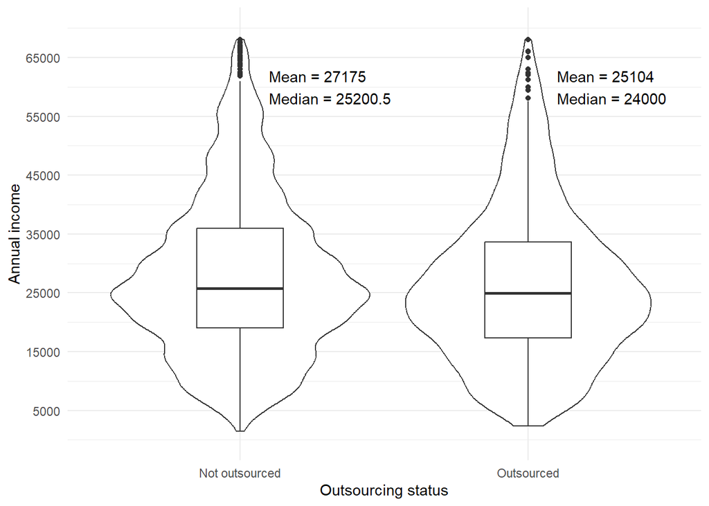

```r
# plot the distribution of income for the two groups
data %>%
  filter(income_drop_all == 0 & !is.na(income_annual_all)) %>%
  ggplot(., aes(outsourcing_status, income_annual_all)) +
  geom_violin() +
  geom_boxplot(width = 0.3) +
  geom_text(inherit.aes=F, data=income_statistics, aes(outsourcing_status, y = 6e+04), label=paste0("Mean = ", round(income_statistics$mean,0),"\n", "Median = ", income_statistics$median), nudge_x = 0.1, hjust=0) +
  coord_cartesian(xlim=c(1,2.5)) +
  theme_minimal() +
  xlab("Outsourcing status") + ylab("Annual income") +
  coord_cartesian(ylim = c(plyr::round_any(min(income_statistics$min), 5000, f = floor),plyr::round_any(max(income_statistics$max),5000, f = ceiling))) +
  scale_y_continuous(breaks = seq(plyr::round_any(min(income_statistics$min), 5000, f = ceiling), plyr::round_any(max(income_statistics$max),5000, f = ceiling), 10000))
```

The distribution for the different outsourcing groups is shown below. It indicates that income is particularly low for the ‘outsourced’ and ‘likely agency’ workers, whilst average income for the ‘high indicators’ workers is notably higher. This means that, were we not to consider the high indicators group, the difference in income between outsrouced and non-outsourced workers would be larger.

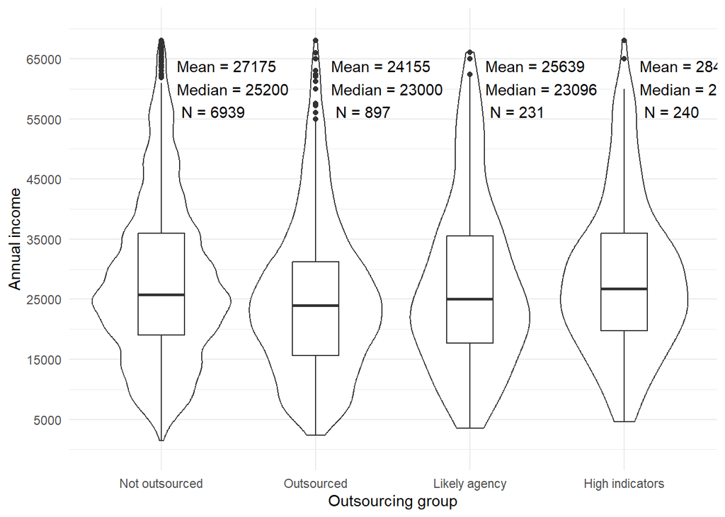

```r
income_statistics <- data %>%
  filter(income_drop_all == 0 & !is.na(income_annual_all)) %>%
  group_by(outsourcing_group) %>%
  summarise(
    n = n(),
    mean = weighted.mean(income_annual_all, w = NatRepemployees, na.rm = T),
    median = wtd.quantile(income_annual_all, w = NatRepemployees, probs = c(.5), na.rm = T),
    min = wtd.quantile(income_annual_all, w = NatRepemployees, probs = c(0), na.rm = T),
    max = wtd.quantile(income_annual_all, w = NatRepemployees, probs = c(1), na.rm = T),
    stdev = sqrt(wtd.var(income_annual_all, w = NatRepemployees, na.rm = T))
  )

data %>%
  filter(income_drop_all == 0 & !is.na(income_annual_all)) %>%
  ggplot(., aes(outsourcing_group, income_annual_all)) +
  geom_violin() +
  geom_boxplot(width = 0.3) +
  geom_text(inherit.aes=F, data=income_statistics, aes(outsourcing_group, y = 6e+04), label=paste0("Mean = ", round(income_statistics$mean,0),"\n", "Median = ", round(income_statistics$median,0),"\n N = ", income_statistics$n), nudge_x = 0.1, hjust=0) +
  coord_cartesian(xlim=c(1,2.5)) +
  theme_minimal() +
  xlab("Outsourcing group") + ylab("Annual income") +
  coord_cartesian(ylim = c(plyr::round_any(min(income_statistics$min), 5000, f = floor),plyr::round_any(max(income_statistics$max),5000, f = ceiling))) +
  scale_y_continuous(breaks = seq(plyr::round_any(min(income_statistics$min), 5000, f = ceiling), plyr::round_any(max(income_statistics$max),5000, f = ceiling), 10000))
```

```r
temp_data <- data %>%
  filter(income_drop == 0 & !is.na(income_annual))

# ttest <- t.test(temp_data[which(temp_data$outsourcing_status=="Outsourced"),"income_annual"],
#        temp_data[which(temp_data$outsourcing_status=="Not outsourced"),"income_annual"]
# )

ttest <-  sjstats::weighted_ttest(income_annual ~ outsourcing_status + NatRepemployees, temp_data)
#cohens_d(ttest)
```

Below, we run a linear regression testing whether the relationship between outsourcing status and annual income is influenced by income group (not low vs low), controlling for age, gender, ethnicity, and region. We do indeed find a significant interaction effect. The figure below plots this.

```r
test <- lm(income_annual ~ Age + Gender + Ethnicity + Region + outsourcing_status*income_group, data, weights = NatRepemployees)
# summary(test)

emmeans(test, specs = "outsourcing_status", by = "income_group")
```

```
income_group = Not low:
 outsourcing_status emmean    SE   df lower.CL upper.CL
 Not outsourced      62912 13148 7360    37139    88686
 Outsourced          90189 13564 7360    63598   116779

income_group = Low:
 outsourcing_status emmean    SE   df lower.CL upper.CL
 Not outsourced      23036 13200 7360    -2840    48912
 Outsourced          21766 13846 7360    -5375    48908

Results are averaged over the levels of: Gender, Region
Confidence level used: 0.95
```

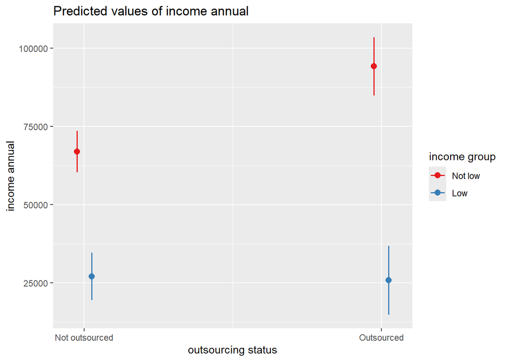

```r
sjPlot::plot_model(test, type = "int")
```

The results here indicate that among workers that are not paid below our low pay threshold, an outsourced worker can typically be expected to earn considerably more than a non-outsourced worker, whereas among workers that are paid below our low pay threshold, an outsourced worker can typically be expected to be paid the same as a non-outsourced worker (maybe slightly less). Of note is that for both pay groups, the variance in pay is higher for the outsourced groups.

### Major group code

Comparison of Majorgroupcode indicates that a higher proportion of outsourced people work in Elementary Occupations, compared to non-outsourced people. A lower proportion of outsourced people work in administrative and secretarial occupations, associate professional occupations and professional occupations.

```r
mgc_summary <- data %>%
  group_by(outsourcing_status,Majorgroupcode) %>%
  summarise(
    Frequency = sum(NatRepemployees),
    avg_income = mean(income_annual, na.rm=T),
    wtd_avg_income = weighted.mean(income_annual, w = NatRepemployees, na.rm=T)
  ) %>%
  mutate(
    Sum = sum(Frequency),
    perc = 100 * (Frequency/Sum)
  )

readr::write_csv(mgc_summary, "../outputs/data/majorgroupcode_summary.csv")
```

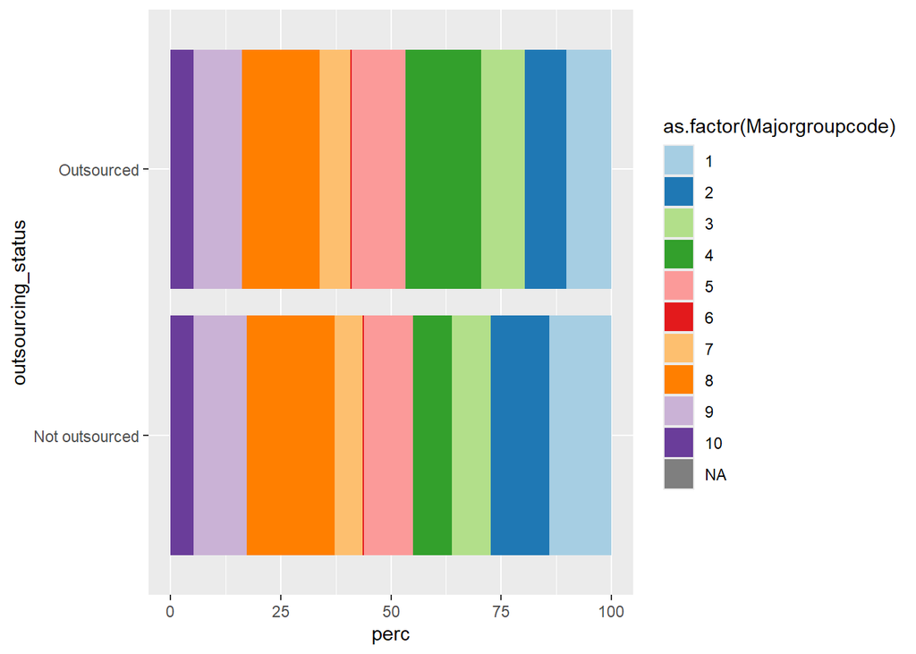

```r
mgc_summary %>%
  ggplot(aes(outsourcing_status, perc, fill = as.factor(Majorgroupcode))) +
  geom_col() +
  coord_flip() +
  scale_fill_manual(values=many_colours)
```

```r
mgc_key <- data.frame("number" = seq(1,11,1),
                            "Major group code" = c( levels(haven::as_factor(mgc_summary$Majorgroupcode)),NA))

mgc_key %>%
  kable() %>%
  kable_styling(full_width = F)
```

| number | Major.group.code |
| --- | --- |
| 1 | ADMINISTRATIVE AND SECRETARIAL OCCUPATIONS |
| 2 | ASSOCIATE PROFESSIONAL OCCUPATIONS |
| 3 | CARING, LEISURE AND OTHER SERVICE OCCUPATIONS |
| 4 | ELEMENTARY OCCUPATIONS |
| 5 | MANAGERS, DIRECTORS AND SENIOR OFFICIALS |
| 6 | NA |
| 7 | PROCESS, PLANT AND MACHINE OPERATIVES |
| 8 | PROFESSIONAL OCCUPATIONS |
| 9 | SALES AND CUSTOMER SERVICE OCCUPATIONS |
| 10 | SKILLED TRADES OCCUPATIONS |
| 11 | NA |

The table below shows the percentage of outsourced and non-outsourced workers in each majorgroupcode, as well as the difference between them (positive numbers in the difference column indicate occupations that are more common for outsourced work, negative numbers indicate occupations that are less common for outsourced work).[^3]

```r
mgc_summary %>%
  select(outsourcing_status, Majorgroupcode, perc) %>%
  pivot_wider(names_from = outsourcing_status, values_from = perc) %>%
  mutate(
    Majorgroupcode = haven::as_factor(Majorgroupcode),
    Difference = `Outsourced` - `Not outsourced`
    ) %>%
  kable(digits = 2) %>%
  kable_styling(full_width = F)
```

| Majorgroupcode | Not outsourced | Outsourced | Difference |
| --- | --- | --- | --- |
| ADMINISTRATIVE AND SECRETARIAL OCCUPATIONS | 14.09 | 10.23 | -3.85 |
| ASSOCIATE PROFESSIONAL OCCUPATIONS | 13.23 | 9.35 | -3.88 |
| CARING, LEISURE AND OTHER SERVICE OCCUPATIONS | 8.85 | 10.00 | 1.14 |
| ELEMENTARY OCCUPATIONS | 8.84 | 17.12 | 8.28 |
| MANAGERS, DIRECTORS AND SENIOR OFFICIALS | 11.07 | 12.23 | 1.16 |
| NA | 0.41 | 0.29 | -0.12 |
| PROCESS, PLANT AND MACHINE OPERATIVES | 6.19 | 6.99 | 0.80 |
| PROFESSIONAL OCCUPATIONS | 19.92 | 17.57 | -2.35 |
| SALES AND CUSTOMER SERVICE OCCUPATIONS | 12.06 | 10.97 | -1.10 |
| SKILLED TRADES OCCUPATIONS | 5.32 | 5.24 | -0.07 |
| NA | 0.01 | NA | NA |

```r
mgc_summary_2 <- data %>%
  group_by(Majorgroupcode,outsourcing_status) %>%
  summarise(
    Frequency = sum(NatRepemployees),
    avg_income = mean(income_annual, na.rm=T),
    wtd_avg_income = weighted.mean(income_annual, w = NatRepemployees, na.rm=T)
  ) %>%
  mutate(
    Sum = sum(Frequency),
    perc = 100 * (Frequency/Sum)
  ) %>%
  drop_na()

mgc_summary_2_wider <- mgc_summary_2 %>%
  select(outsourcing_status, Majorgroupcode, perc) %>%
  pivot_wider(names_from = outsourcing_status, values_from = perc) %>%
  mutate(
    Majorgroupcode = haven::as_factor(Majorgroupcode),
    #Difference = `Outsourced` - `Not outsourced`,
    Ratio_10 = 10 * (`Outsourced` / `Not outsourced`) # indicates how many outsourced workers there are for every 10 non outsourced
    )

mgc_summary_2_wider %>%
  kable(digits = 2) %>%
  kable_styling(full_width = F)
```

| Majorgroupcode | Not outsourced | Outsourced | Ratio_10 |
| --- | --- | --- | --- |
| ADMINISTRATIVE AND SECRETARIAL OCCUPATIONS | 87.19 | 12.81 | 1.47 |
| ASSOCIATE PROFESSIONAL OCCUPATIONS | 87.49 | 12.51 | 1.43 |
| CARING, LEISURE AND OTHER SERVICE OCCUPATIONS | 81.41 | 18.59 | 2.28 |
| ELEMENTARY OCCUPATIONS | 71.86 | 28.14 | 3.92 |
| MANAGERS, DIRECTORS AND SENIOR OFFICIALS | 81.73 | 18.27 | 2.24 |
| NA | 87.59 | 12.41 | 1.42 |
| PROCESS, PLANT AND MACHINE OPERATIVES | 81.41 | 18.59 | 2.28 |
| PROFESSIONAL OCCUPATIONS | 84.86 | 15.14 | 1.78 |
| SALES AND CUSTOMER SERVICE OCCUPATIONS | 84.47 | 15.53 | 1.84 |
| SKILLED TRADES OCCUPATIONS | 83.37 | 16.63 | 1.99 |

```r
readr::write_csv(mgc_summary_2, "../outputs/data/majorgroupcode_summary_2_long.csv")

readr::write_csv(mgc_summary_2_wider, "../outputs/data/majorgroupcode_summary_2_wide.csv")
```

The plot below summarises the average pay (x-axis) in each occupation (y-axis) for outsourced and non-outsourced workers (dot colour), as well as the size of the respective workforce (size of dots). Here the size of the dot represents the percentage of workers *within* the sector who are outsourced (blue) or not outsourced (purple).[^4]

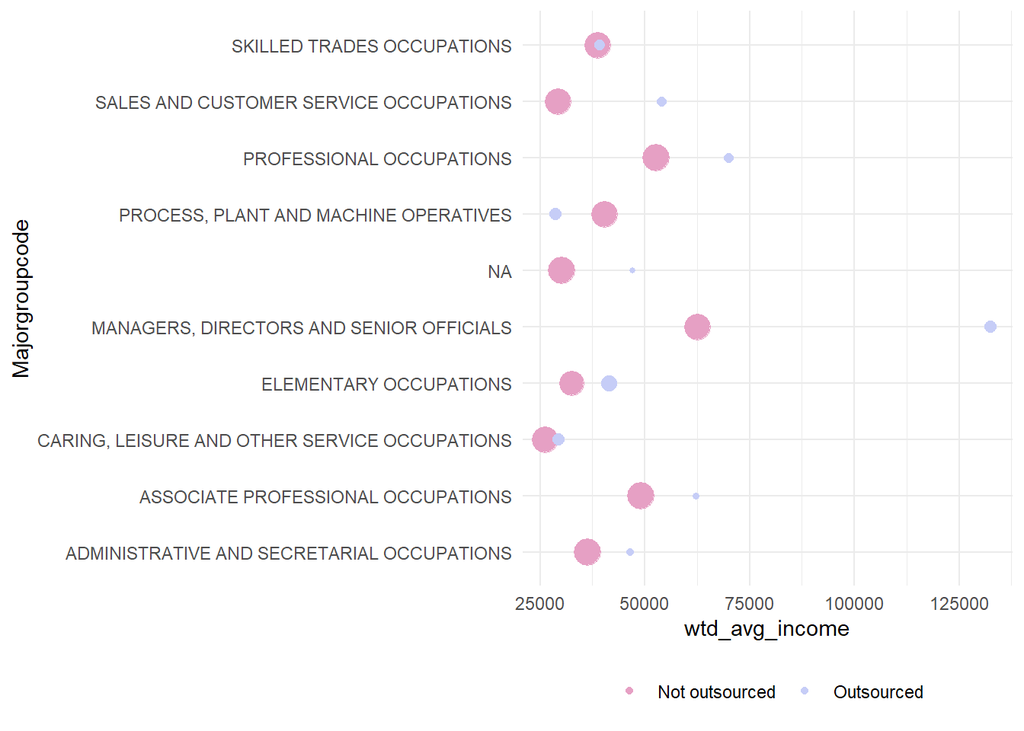

```r
mgc_summary_2 %>%
  mutate(
    Majorgroupcode = haven::as_factor(Majorgroupcode)
  ) %>%
  ggplot(., aes(Majorgroupcode, wtd_avg_income, size = perc, colour = outsourcing_status)) +
    geom_point(position = "dodge") +
    coord_flip() +
  theme_minimal() +
  theme(legend.position = "bottom",
        legend.title = element_blank())+
  scale_y_continuous(breaks=seq(0,max(mgc_summary$wtd_avg_income), 25000)) +
  scale_colour_manual(values=colours) +
  guides(size=FALSE) # remove size legend as gauging size is difficult
```

It shows, as might be expected, the size of the outsourced workforce for each sector is smaller than the non-outsourced workforce, but the ratio is not the same for all sectors. The sector with the largest non-outsourced:outsourced ratio is Elementary occupations; **for every 10 non-outsourced workers, there are 4 outsourced workers**. This is followed by caring, leisure, and other service occupations, and process, plant and machine operatives, both of which employ **2 outsourced workers for every 10 non-outsourced workers**.

Notably, in elementary occupations and sales and customer service occupations, outsourced workers are on average paid more than non-outsourced workers. In contrast, workers in process, plant and machine operations are paid less if they are outsourced than if they are not outsourced.

#### Unit occupations

A deep dive into elementary occupations, process occupations, and caring occupations reveals that there are differences between occupations in the size of the outsourced workforce and pay.

##### Elementary occupations[^5]

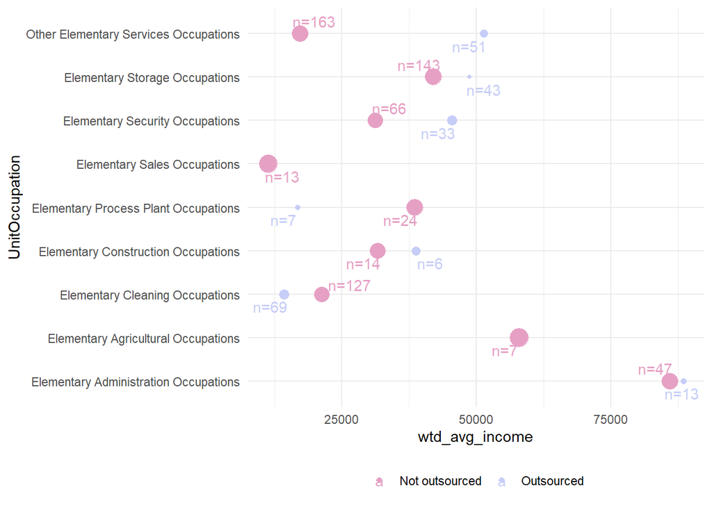

```r
elem_summary <- data %>%
  filter(Majorgroupcode %in% c(4)) %>%
  group_by(UnitOccupation,outsourcing_status) %>%
  summarise(
    n = n(),
    Frequency = sum(NatRepemployees),
    avg_income = mean(income_annual, na.rm=T),
    wtd_avg_income = weighted.mean(income_annual, w = NatRepemployees, na.rm=T)
  ) %>%
  mutate(
    Sum = sum(Frequency),
    perc = 100 * (Frequency/Sum)
  ) %>%
  drop_na()

elem_summary %>%
  mutate(
    UnitOccupation = haven::as_factor(UnitOccupation)
  ) %>%
  ggplot(., aes(wtd_avg_income,UnitOccupation, size = perc, colour = outsourcing_status)) +
    geom_point() +
    geom_text_repel(inherit.aes = F, aes(wtd_avg_income, UnitOccupation, colour = outsourcing_status, label=paste0("n=",n))) +
  #coord_flip() +

  theme_minimal() +
  theme(legend.position = "bottom",
        legend.title = element_blank()) +
  # scale_x_continuous(breaks=scales::pretty(10))
  scale_colour_manual(values=colours) +

    guides(size=FALSE)
```

```r
readr::write_csv(elem_summary, "../outputs/data/elementary_occs_summary.csv")
```

##### Process occupations[^6]

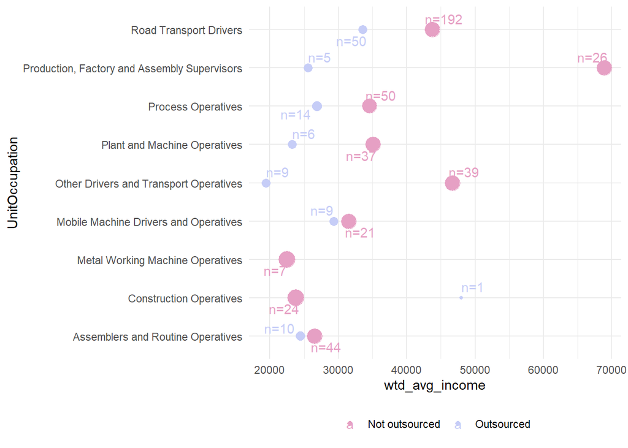

```r
proc_summary <- data %>%
  filter(Majorgroupcode %in% c(7)) %>%
  group_by(UnitOccupation,outsourcing_status) %>%
  summarise(
    n = n(),
    Frequency = sum(NatRepemployees),
    avg_income = mean(income_annual, na.rm=T),
    wtd_avg_income = weighted.mean(income_annual, w = NatRepemployees, na.rm=T)
  ) %>%
  mutate(
    Sum = sum(Frequency),
    perc = 100 * (Frequency/Sum)
  ) %>%
  drop_na()

proc_summary %>%
  mutate(
    UnitOccupation = haven::as_factor(UnitOccupation)
  ) %>%
  ggplot(., aes(wtd_avg_income,UnitOccupation, size = perc, colour = outsourcing_status)) +
    geom_point() +
    geom_text_repel(inherit.aes = F, aes(wtd_avg_income, UnitOccupation, colour = outsourcing_status, label=paste0("n=",n))) +
  #coord_flip() +

  theme_minimal() +
  theme(legend.position = "bottom",
        legend.title = element_blank()) +
  # scale_x_continuous(breaks=scales::pretty(10))
  scale_colour_manual(values=colours) +

    guides(size=FALSE)
```

```r
readr::write_csv(proc_summary, "../outputs/data/process_occs_summary.csv")
```

##### Caring occupations[^7]

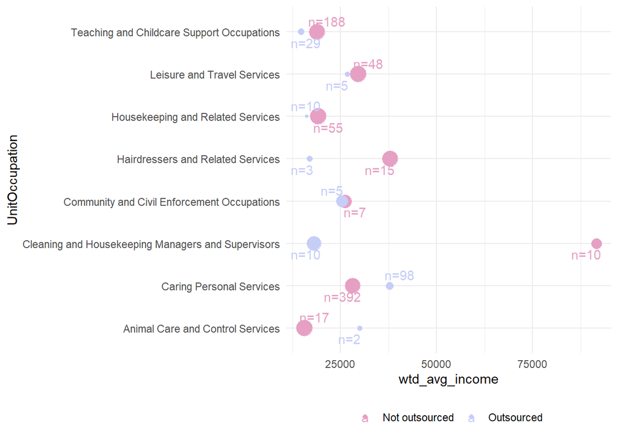

```r
caring_summary <- data %>%
  filter(Majorgroupcode %in% c(3)) %>%
  group_by(UnitOccupation,outsourcing_status) %>%
  summarise(
    n = n(),
    Frequency = sum(NatRepemployees),
    avg_income = mean(income_annual, na.rm=T),
    wtd_avg_income = weighted.mean(income_annual, w = NatRepemployees, na.rm=T)
  ) %>%
  mutate(
    Sum = sum(Frequency),
    perc = 100 * (Frequency/Sum)
  ) %>%
  drop_na()

caring_summary %>%
  mutate(
    UnitOccupation = haven::as_factor(UnitOccupation)
  ) %>%
  ggplot(., aes(wtd_avg_income,UnitOccupation, size = perc, colour = outsourcing_status)) +
    geom_point() +
    geom_text_repel(inherit.aes = F, aes(wtd_avg_income, UnitOccupation, colour = outsourcing_status, label=paste0("n=",n))) +
  #coord_flip() +

  theme_minimal() +
  theme(legend.position = "bottom",
        legend.title = element_blank()) +
  # scale_x_continuous(breaks=scales::pretty(10))
  scale_colour_manual(values=colours) +

    guides(size=FALSE)
```

```r
readr::write_csv(caring_summary, "../outputs/data/caring_occs_summary.csv")
```

### Sector

#### Sector within outsourcing status

This framing shows how outsourced and non-outsourced workers are distributed across sectors.

```r
sector_summary <- data %>%
  group_by(outsourcing_status, SectorName, SectorName_labelled) %>%
  summarise(
    Frequency = sum(NatRepemployees),
    avg_income = mean(income_annual, na.rm=T),
    wtd_avg_income = weighted.mean(income_annual, w = NatRepemployees, na.rm=T)
  ) %>%
  ungroup() %>%
  group_by(outsourcing_status) %>%
  mutate(
    Sum = sum(Frequency),
    perc = 100 * (Frequency/Sum),
    SectorName_labelled = case_when(SectorName_labelled == "NA" ~ NA,
                                    TRUE ~ SectorName_labelled),
    SectorName_short = SectorName_labelled
  ) %>%
  # make the sector names more readable
  separate_wider_delim(SectorName_short, names = c("SectorName_short", "SectorName_short_detail"), delim=";",
                       too_few = "align_start") %>%
  mutate(
    SectorName_short = factor(stringr::str_to_sentence(SectorName_short)),
    SectorName_short_detail = factor(stringr::str_to_sentence(SectorName_short_detail)),
  )



readr::write_csv(sector_summary, "../outputs/data/sector_summary.csv")
```

The plot below shows the sector breakdown by outsourcing status. I.e. this is how outsourced and not outsourced workers are distributed across sectors.[^8]

**Note**

With this framing we could say things like “as an outsourced worker, you are x times more likely to work in than a non-outsourced worker”

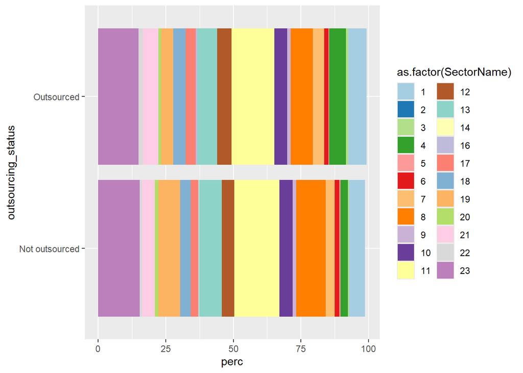

```r
plot_data <- sector_summary %>%
  drop_na(SectorName_labelled) %>%
  droplevels()

plot_data %>%
  ggplot(aes(outsourcing_status, perc, fill = as.factor(SectorName))) +
  geom_col() +
  coord_flip() +
  scale_fill_manual(values=many_colours)
```

```r
sector_key <- data.frame("number" = seq(1,length(unique(plot_data$SectorName)),1),
                            "Sector" = levels(plot_data$SectorName_labelled))

sector_key %>%
  kable() %>%
  kable_styling(full_width = F)
```

| number | Sector |
| --- | --- |
| 1 | ACCOMMODATION AND FOOD SERVICE ACTIVITIES |
| 2 | ACTIVITIES OF EXTRATERRITORIAL ORGANISATIONS AND BODIES |
| 3 | ACTIVITIES OF HOUSEHOLDS AS EMPLOYERS; UNDIFFERENTIATED GOODS-AND SERVICES-PRODUCING ACTIVITIES OF HOUSEHOLDS FOR OWN US |
| 4 | ADMINISTRATIVE AND SUPPORT SERVICE ACTIVITIES |
| 5 | AGRICULTURE, FORESTRY AND FISHING |
| 6 | ARTS, ENTERTAINMENT AND RECREATION |
| 7 | CONSTRUCTION |
| 8 | EDUCATION |
| 9 | ELECTRICITY, GAS, STEAM AND AIR CONDITIONING SUPPLY |
| 10 | FINANCIAL AND INSURANCE ACTIVITIES |
| 11 | HUMAN HEALTH AND SOCIAL WORK ACTIVITIES |
| 12 | INFORMATION AND COMMUNICATION |
| 13 | MANUFACTURING |
| 14 | MINING AND QUARRYING |
| 15 | Not found |
| 16 | OTHER SERVICE ACTIVITIES |
| 17 | PROFESSIONAL, SCIENTIFIC AND TECHNICAL ACTIVITIES |
| 18 | PUBLIC ADMINISTRATION AND DEFENCE; COMPULSORY SOCIAL SECURITY |
| 19 | REAL ESTATE ACTIVITIES |
| 20 | TRANSPORTATION AND STORAGE |
| 21 | WATER SUPPLY; SEWERAGE, WASTE MANAGEMENT AND REMEDIATION ACTIVITIES |
| 22 | WHOLESALE AND RETAIL TRADE; REPAIR OF MOTOR VEHICLES AND MOTORCYCLES |

The table below shows what percentage of outsourced and non-outsourced workers work in each sector, as well as the difference between them (positive numbers in the difference column indicate sectors that are more common for outsourced work, negative numbers indicate sectors that are less common for outsourced work).[^9]

It indicates that sectors that are *less common* for outsourced workers compared to not outsourced are:

- PUBLIC ADMINISTRATION AND DEFENCE; COMPULSORY SOCIAL SECURITY
- EDUCATION

And sectors that are *more common* for outsourced workers compared to not outsourced are:

- ADMINISTRATIVE AND SUPPORT SERVICE ACTIVITIES

For these sectors that differ most in the concentration of the outsourced workforce, there is a pattern (if three data points can be called that) whereby in sectors with a relatively higher concentration of outsourced workers, outsourced workers are paid less, and in sectors with a relatively lower concentration of outsourced workers, outsourced workers are paid more. This is tenuous, but it is an example of the heterogeneity in income between sectors, and should be explored further.

```r
sector_summary_2 <- plot_data %>%
  select(outsourcing_status, SectorName, SectorName_short, perc, wtd_avg_income) %>%
  pivot_wider(names_from = outsourcing_status, values_from = c(perc, wtd_avg_income)) %>%
  mutate(
    perc_difference = `perc_Outsourced` - `perc_Not outsourced`,
    income_difference = `wtd_avg_income_Outsourced` - `wtd_avg_income_Not outsourced`
    ) %>%
  relocate(
    perc_difference, .after = perc_Outsourced
  )

sector_summary_2 %>%
  arrange(desc(abs(perc_difference))) %>%
  kable(digits = 2) %>%
  kable_styling(full_width = F)
```

| SectorName | SectorName_short | perc_Not outsourced | perc_Outsourced | perc_difference | wtd_avg_income_Not outsourced | wtd_avg_income_Outsourced | income_difference |
| --- | --- | --- | --- | --- | --- | --- | --- |
| 19 | Public administration and defence | 7.98 | 4.41 | -3.57 | 44269.46 | 80688.11 | 36418.64 |
| 4 | Administrative and support service activities | 2.76 | 6.30 | 3.54 | 34008.23 | 25773.63 | -8234.59 |
| 8 | Education | 11.00 | 8.17 | -2.83 | 42664.00 | 66203.95 | 23539.95 |
| 13 | Manufacturing | 8.39 | 7.28 | -1.10 | 47496.16 | 61992.04 | 14495.88 |
| 11 | Human health and social work activities | 16.74 | 15.81 | -0.93 | 34943.28 | 37315.45 | 2372.18 |
| 21 | Transportation and storage | 4.86 | 5.79 | 0.93 | 50974.51 | 40399.44 | -10575.07 |
| 7 | Construction | 3.22 | 4.13 | 0.91 | 57729.30 | 79257.70 | 21528.41 |
| 17 | Other service activities | 2.77 | 3.66 | 0.89 | 39021.24 | 49283.90 | 10262.65 |
| 22 | Water supply | 0.76 | 1.62 | 0.85 | 46514.17 | 50316.51 | 3802.34 |
| 1 | Accommodation and food service activities | 5.89 | 6.71 | 0.83 | 23814.49 | 46561.01 | 22746.52 |
| 12 | Information and communication | 4.58 | 5.32 | 0.74 | 63987.91 | 97333.04 | 33345.13 |
| 18 | Professional, scientific and technical activities | 3.92 | 4.66 | 0.74 | 53888.29 | 69683.01 | 15794.72 |
| 3 | Activities of households as employers | 0.31 | 0.86 | 0.54 | 57350.92 | 21162.34 | -36188.59 |
| 23 | Wholesale and retail trade | 15.43 | 14.93 | -0.49 | 36426.50 | 59181.02 | 22754.52 |
| 16 | Not found | 0.30 | 0.68 | 0.38 | 30372.90 | 30421.16 | 48.26 |
| 20 | Real estate activities | 1.25 | 0.97 | -0.29 | 39630.78 | 27557.00 | -12073.78 |
| 6 | Arts, entertainment and recreation | 1.81 | 1.61 | -0.20 | 26930.44 | 21607.35 | -5323.09 |
| 5 | Agriculture, forestry and fishing | 0.42 | 0.22 | -0.20 | 36423.88 | 25767.70 | -10656.18 |
| 9 | Electricity, gas, steam and air conditioning supply | 1.21 | 1.32 | 0.10 | 84854.37 | 73130.20 | -11724.17 |
| 10 | Financial and insurance activities | 4.91 | 4.81 | -0.10 | 62097.41 | 143214.64 | 81117.23 |
| 2 | Activities of extraterritorial organisations and bodies | 0.04 | NA | NA | 32367.32 | NA | NA |
| 14 | Mining and quarrying | 0.10 | NA | NA | 54859.57 | NA | NA |

```r
readr::write_csv(sector_summary_2, file="../outputs/data/sector_summary_2.csv")
```

The plot below plots the percentage difference in the concentration of outsourced vs non-outsourced workers (i.e. the difference between what proportion of workers of each type are in each sector) against the income difference for that sector (i.e., the difference in the average income between groups). Note that a statistical test of this relationship shows it is non-significant. This plot therefore only serves as an illustration of where workers are situated in terms of sector and pay. A key takeaway here is that there is considerable variation in the difference in pay between outsourced and non-outsourced workers. There also appears to be a central area where the concentration of outsourced vs non-outsourced workers is quite similar, but the pay for outsourced workers is lower. This might indicate sectors where employment of outsourced workers is as common as employment of non-outsourced workers, but where outsourced workers are paid less than non-outsourced workers. These sectors are:

- 5: AGRICULTURE, FORESTRY AND FISHING
- 6: ARTS, ENTERTAINMENT AND RECREATION
- 9: ELECTRICITY, GAS, STEAM AND AIR CONDITIONING SUPPLY
- 20: REAL ESTATE ACTIVITIES

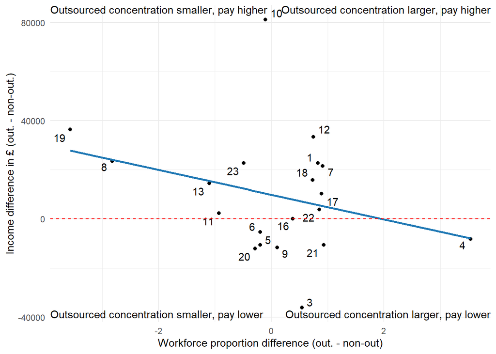

```r
annotations <- data.frame(
        xpos = c(-Inf,-Inf,Inf,Inf), # this sets to corners
        ypos =  c(-Inf, Inf,-Inf,Inf), # this sets to corners
        annotateText = c("Outsourced concentration smaller, pay lower","Outsourced concentration smaller, pay higher",
                        "Outsourced concentration larger, pay lower","Outsourced concentration larger, pay higher"),
        hjustvar = c(0,0,1,1), # higher values = right, lower values = left
        vjustvar = c(-0.5,1,-0.5,1) # higher values = up, lower values = down
        )

sector_summary_2 %>%
  ggplot(aes(perc_difference, income_difference)) +
  geom_point() +
  geom_smooth(method="lm", colour=many_colours[2], se=FALSE) +
  theme_minimal() +
  ylab("Income difference in £ (out. - non-out.)") + xlab("Workforce proportion difference (out. - non-out)") +
  geom_text_repel(aes(label=as.character(SectorName))) +
  geom_text(inherit.aes = F, data = annotations, aes(xpos, ypos, label=annotateText, hjust=hjustvar, vjust=vjustvar)) +
  geom_hline(yintercept = 0, colour="red",linetype="dashed")
```

```r
test <- lm(income_difference ~ perc_difference, sector_summary_2)
summary(test)
```

```
Call:
lm(formula = income_difference ~ perc_difference, data = sector_summary_2)

Residuals:
   Min     1Q Median     3Q    Max
-43309 -15858   -750   9840  70740

Coefficients:
                Estimate Std. Error t value Pr(>|t|)
(Intercept)         9860       5442   1.812   0.0867 .
perc_difference    -5043       3792  -1.330   0.2001
---
Signif. codes:  0 '***' 0.001 '**' 0.01 '*' 0.05 '.' 0.1 ' ' 1

Residual standard error: 24330 on 18 degrees of freedom
  (2 observations deleted due to missingness)
Multiple R-squared:  0.08948,   Adjusted R-squared:  0.0389
F-statistic: 1.769 on 1 and 18 DF,  p-value: 0.2001
```

#### Outsourcing status within sector[^10]

This framing shows how sectors are composed, i.e., what proportion of workers in each sector are outsourced vs non-outsourced.

```r
sector_summary_3 <- data %>%
  group_by(SectorName, SectorName_labelled, outsourcing_status) %>%
  summarise(
    n = n(),
    Frequency = sum(NatRepemployees),
    avg_income = mean(income_annual, na.rm=T),
    wtd_avg_income = weighted.mean(income_annual, w = NatRepemployees, na.rm=T)
  ) %>%
  ungroup() %>%
  group_by(SectorName) %>%
  mutate(
    N = sum(n),
    Sum = sum(Frequency),
    perc = 100 * (Frequency/Sum),
    SectorName_labelled = case_when(SectorName_labelled == "NA" ~ NA,
                                    TRUE ~ SectorName_labelled),
    SectorName_short = SectorName_labelled
  ) %>%
  # make the sector names more readable
  separate_wider_delim(SectorName_short, names = c("SectorName_short", "SectorName_short_detail"), delim=";",
                       too_few = "align_start") %>%
  mutate(
    SectorName_short = factor(stringr::str_to_sentence(SectorName_short)),
    SectorName_short_detail = factor(stringr::str_to_sentence(SectorName_short_detail)),
  )

write_csv(sector_summary_3, file="../outputs/data/sector_summary_3.csv")
```

The plot below shows the proportion of outsourced and not outsourced workers within each sector. I.e. this is showing what sectors have higher and lower proportions of outsourced workers.

**Note**

With this framing we could say things like “sector a is x times more likely to employ outsourced workers than sector b”

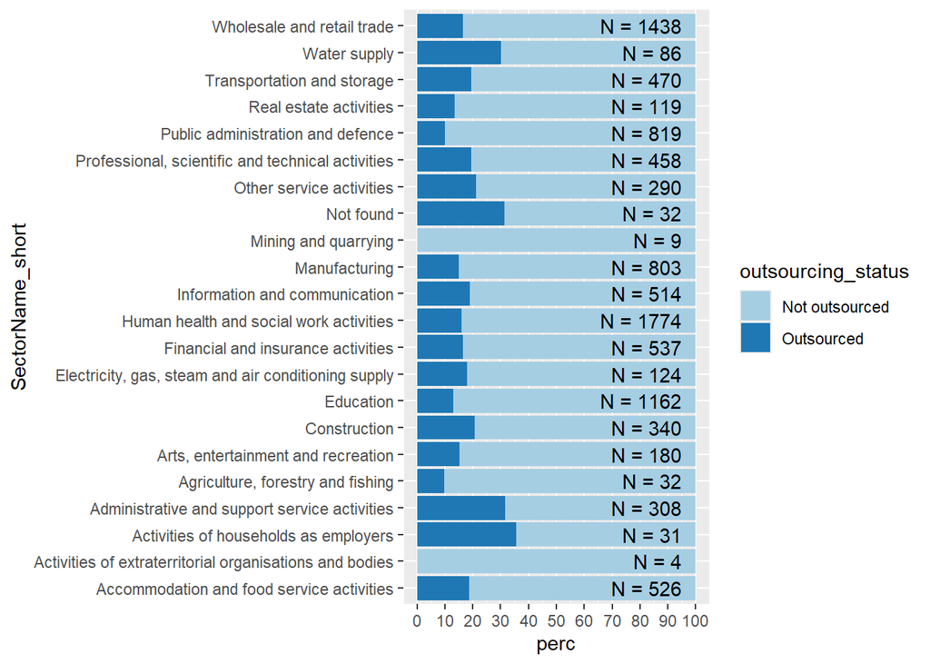

```r
plot_data <- sector_summary_3 %>%
  drop_na(SectorName_short) %>%
  droplevels()

# annotation_df <- plot_data %>%
#   select(SectorName_short, outsourcing_status, perc, n
# mutate(

annotation_df <- plot_data %>%
  filter(outsourcing_status == "Not outsourced") %>%
  select(SectorName_short, N) %>%
  mutate(
    ypos = 80
  )


ggplot(plot_data,aes(SectorName_short, perc, fill = outsourcing_status)) +
  geom_col() +
  geom_text(inherit.aes=F,data=annotation_df, aes(x=SectorName_short, y=ypos, label = paste0("N = ", N)), hjust=1, nudge_y = 15) +
  coord_flip() +
  scale_fill_manual(values=many_colours) +
  scale_y_continuous(breaks=seq(0,100,10))
```

```r
# sector_key <- data.frame("number" = seq(1,length(unique(plot_data$SectorName_labelled)),1),
#                           "Sector" = levels(plot_data$SectorName_labelled))
#
# sector_key %>%
#   kable() %>%
#   kable_styling(full_width = F)
```

The table below shows the percentage of outsourced workers in each Sector, ordered descending by percentage. It shows that the top three Sectors with the highest proportion of outsourced workers are:

- ACTIVITIES OF HOUSEHOLDS AS EMPLOYERS; UNDIFFERENTIATED GOODS-AND SERVICES-PRODUCING ACTIVITIES OF HOUSEHOLDS FOR OWN US (note that N = 31)
- ADMINISTRATIVE AND SUPPORT SERVICE ACTIVITIES
- WATER SUPPLY; SEWERAGE, WASTE MANAGEMENT AND REMEDIATION ACTIVITIES

Note that for an undefined sector (‘Not found’) contained one of the largest proportions of outsourced workers (31% of workers in the ‘Not found’ category were outsourced).

```r
plot_data %>%
  filter(outsourcing_status == "Outsourced") %>%
  arrange(desc(perc)) %>%
  select(SectorName_labelled, perc) %>%
  kable() %>%
  kable_styling()
```

| SectorName | SectorName_labelled | perc |
| --- | --- | --- |
| 3 | ACTIVITIES OF HOUSEHOLDS AS EMPLOYERS; UNDIFFERENTIATED GOODS-AND SERVICES-PRODUCING ACTIVITIES OF HOUSEHOLDS FOR OWN US | 35.652378 |
| 4 | ADMINISTRATIVE AND SUPPORT SERVICE ACTIVITIES | 31.570055 |
| 16 | Not found | 31.317619 |
| 22 | WATER SUPPLY; SEWERAGE, WASTE MANAGEMENT AND REMEDIATION ACTIVITIES | 30.008923 |
| 17 | OTHER SERVICE ACTIVITIES | 21.102417 |
| 7 | CONSTRUCTION | 20.589291 |
| 21 | TRANSPORTATION AND STORAGE | 19.415919 |
| 18 | PROFESSIONAL, SCIENTIFIC AND TECHNICAL ACTIVITIES | 19.369714 |
| 12 | INFORMATION AND COMMUNICATION | 19.034279 |
| 1 | ACCOMMODATION AND FOOD SERVICE ACTIVITIES | 18.738635 |
| 9 | ELECTRICITY, GAS, STEAM AND AIR CONDITIONING SUPPLY | 18.008232 |
| 10 | FINANCIAL AND INSURANCE ACTIVITIES | 16.529705 |
| 23 | WHOLESALE AND RETAIL TRADE; REPAIR OF MOTOR VEHICLES AND MOTORCYCLES | 16.373830 |
| 11 | HUMAN HEALTH AND SOCIAL WORK ACTIVITIES | 16.037739 |
| 6 | ARTS, ENTERTAINMENT AND RECREATION | 15.255060 |
| 13 | MANUFACTURING | 14.939669 |
| 20 | REAL ESTATE ACTIVITIES | 13.504099 |
| 8 | EDUCATION | 13.065534 |
| 19 | PUBLIC ADMINISTRATION AND DEFENCE; COMPULSORY SOCIAL SECURITY | 10.051123 |
| 5 | AGRICULTURE, FORESTRY AND FISHING | 9.709408 |

Exploring this workforce makeup in the context of income shows that there are some sectors where outsourced workers are paid more and some where they are paid less than non-outsourced workers. The plot below visualises this.

Sectors where outsourced workers are paid less:

Sectors where outsourced workers are paid more:

Note that in 2 or 3 of the Sectors where outsourced workers are paid less are low-paying Sectors. (this needs to be double-checked)

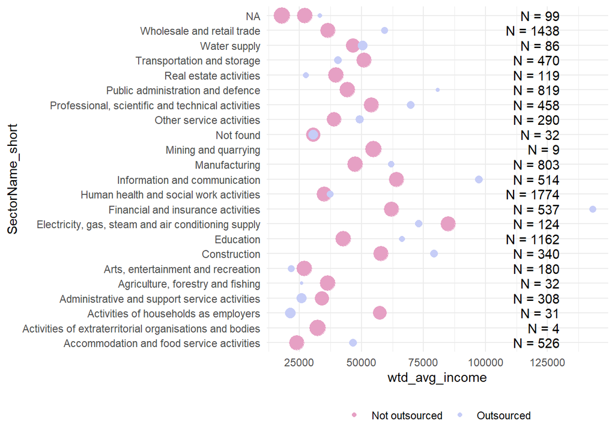

```r
annotation_df <- sector_summary_3 %>%
  filter(outsourcing_status == "Not outsourced") %>%
  select(SectorName_short, N) %>%
  group_by(SectorName_short) %>%
  summarise(
    N = sum(N)
  ) %>%
    mutate(
    ypos = 110000
  )

sector_summary_3 %>%
  # mutate(
  #   SectorName = as.factor(SectorName)
  # ) %>%
  ggplot(., aes(wtd_avg_income,SectorName_short, size = perc, colour = outsourcing_status)) +
    geom_point(position = "dodge") +
  theme_minimal() +
  theme(legend.position = "bottom",
        legend.title = element_blank())+
      #coord_flip() +
  scale_x_continuous(breaks=seq(0,max(sector_summary$wtd_avg_income), 25000)) +
  scale_colour_manual(values=colours) +
  geom_text(inherit.aes=F,data=annotation_df, aes(x=ypos, y=SectorName_short, label = paste0("N = ", N)), hjust=1, nudge_x=20000) +
  guides(size=FALSE) # remove size legend as gauging size is difficult
```

##### Apply the paysplit[^11]

```r
sector_summary_paysplit <- data %>%
  group_by(SectorName, SectorName_labelled, income_group, outsourcing_status) %>%
  drop_na(income_group) %>%
  summarise(
    n = n(),
    Frequency = sum(NatRepemployees),
    avg_income = mean(income_annual, na.rm=T),
    wtd_avg_income = weighted.mean(income_annual, w = NatRepemployees, na.rm=T)
  ) %>%
  ungroup() %>%
  group_by(SectorName, income_group) %>%
  mutate(
    N = sum(n),
    Sum = sum(Frequency),
    perc = 100 * (Frequency/Sum),
    SectorName_labelled = case_when(SectorName_labelled == "NA" ~ NA,
                                    TRUE ~ SectorName_labelled),
    SectorName_short = SectorName_labelled
  ) %>%
  # make the sector names more readable
  separate_wider_delim(SectorName_short, names = c("SectorName_short", "SectorName_short_detail"), delim=";",
                       too_few = "align_start") %>%
  mutate(
    SectorName_short = factor(stringr::str_to_sentence(SectorName_short)),
    SectorName_short_detail = factor(stringr::str_to_sentence(SectorName_short_detail)),
  )

write_csv(sector_summary_paysplit, file="../outputs/sector_summary_paysplit.csv")
```

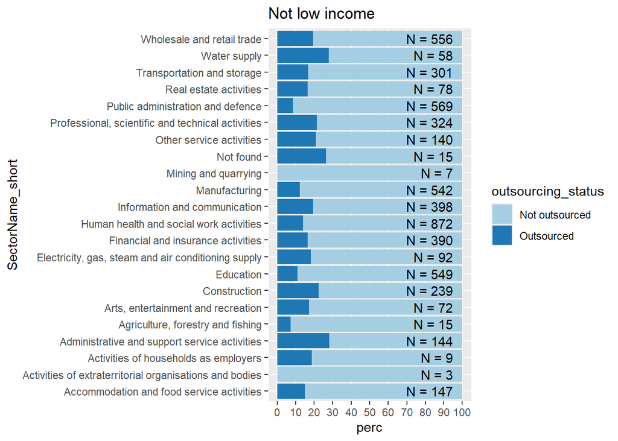

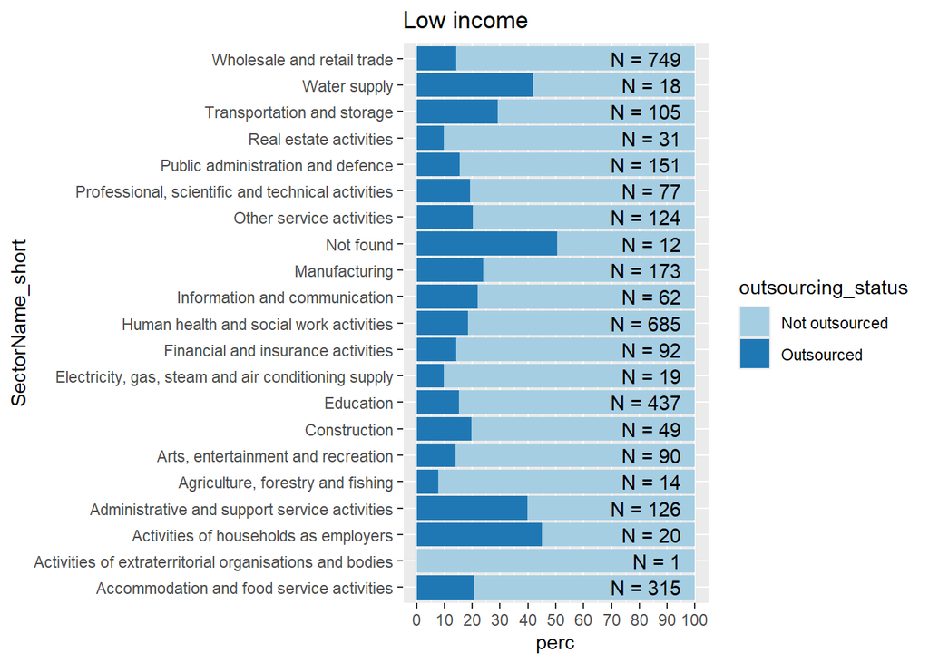

```r
for(group in unique(sector_summary_paysplit$income_group)){

  plot_data <- sector_summary_paysplit %>%
    filter(income_group==group) %>%
    drop_na(SectorName_short) %>%
    droplevels()

  # set ypos for labels
  max_value <- max(plot_data$perc)
  ypos <- 0.8 * max_value

  annotation_df <- plot_data %>%
    filter(outsourcing_status == "Not outsourced") %>%
    select(SectorName_short, N) %>%
    group_by(SectorName_short) %>%
    mutate(
      ypos = ypos
    )

  plot <- ggplot(plot_data, aes(SectorName_short, perc, fill = outsourcing_status)) +
    geom_col() +
    geom_text(inherit.aes=F,data=annotation_df, aes(x=SectorName_short, y=ypos, label = paste0("N = ", N)), hjust=1, nudge_y = 15) +
    coord_flip() +
    scale_fill_manual(values=many_colours) +
    scale_y_continuous(breaks=seq(0,100,10)) +
    ggtitle(paste0(group, " income"))

  print(plot)

}
```

The percentages below show be read as e.g. 20% of low paid workers in accommodation and food services are outsourced, compared to 16% of not low paid workers in accommodation and food services.

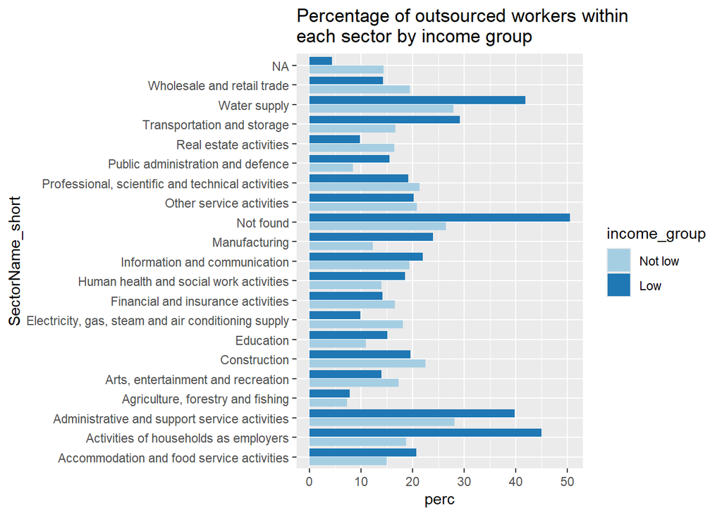

```r
plot_data <- sector_summary_paysplit %>%
  filter(outsourcing_status=="Outsourced")

max_value <- max(plot_data$perc)
ypos <- 0.8 * max_value

annotation_df <- plot_data %>%
  filter(outsourcing_status == "Outsourced") %>%
  select(SectorName_short, income_group, N) %>%
  group_by(SectorName_short) %>%
  mutate(

    ypos = ypos
  )

ggplot(plot_data, aes(SectorName_short, perc, fill = income_group)) +
    geom_col(position = position_dodge2()) +
    # geom_text(inherit.aes=F,data=annotation_df, aes(x=SectorName_short, y=ypos, label = paste0("N = ", N)), position = position_dodge(width=2)) +
    coord_flip() +
    scale_fill_manual(values=many_colours) +
    scale_y_continuous(breaks=seq(0,50,10)) +
    ggtitle("Percentage of outsourced workers within\neach sector by income group")
```

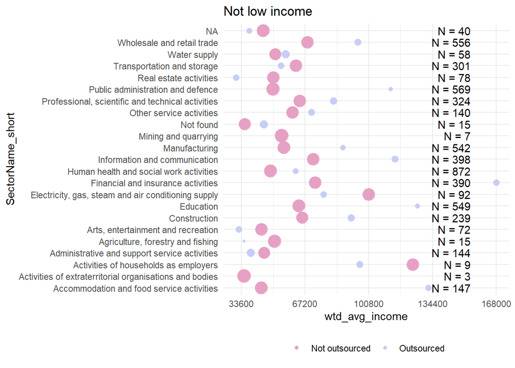

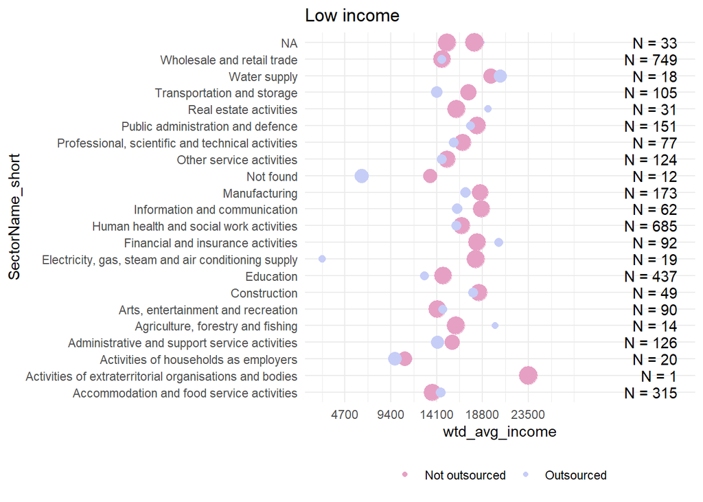

```r
for(group in unique(sector_summary_paysplit$income_group)){
  # set ypos for labels
  max_income <- max(sector_summary_paysplit$wtd_avg_income[which(sector_summary_paysplit$income_group==group)])
  ypos <- 0.8 * max_income

  annotation_df <- sector_summary_paysplit %>%
    filter(income_group==group) %>%
    filter(outsourcing_status == "Not outsourced") %>%
    select(SectorName_short, N) %>%
    group_by(SectorName_short) %>%
    summarise(
      N = sum(N)
    ) %>%
    mutate(
      ypos = ypos
    )

  plot <- sector_summary_paysplit %>%
    filter(income_group == group) %>%
    ggplot(., aes(wtd_avg_income,SectorName_short, size = perc, colour = outsourcing_status)) +
      geom_point(position = "dodge") +
    theme_minimal() +
    theme(legend.position = "bottom",
          legend.title = element_blank())+
        #coord_flip() +
    scale_x_continuous(breaks=seq(0,max_income, plyr::round_any(max_income/5, 100))) +
    scale_colour_manual(values=colours) +
    geom_text(inherit.aes=F,data=annotation_df, aes(x=ypos, y=SectorName_short, label = paste0("N = ", N)), hjust=1, nudge_x=20000) +
    guides(size=FALSE) + # remove size legend as gauging size is difficult
    ggtitle(paste0(group, " income"))

  print(plot)
}
```

### Sector repeat: Outsourcing group

```r
sector_summary <- data %>%
  group_by(outsourcing_group, SectorName, SectorName_labelled) %>%
  summarise(
    n = n(),
    Frequency = sum(NatRepemployees),
    avg_income = mean(income_annual, na.rm=T),
    wtd_avg_income = weighted.mean(income_annual, w = NatRepemployees, na.rm=T)
  ) %>%
  ungroup() %>%
  group_by(outsourcing_group) %>%
  mutate(
    N = sum(n),
    Sum = sum(Frequency),
    perc = 100 * (Frequency/Sum),
    SectorName_labelled = case_when(SectorName_labelled == "NA" ~ NA,
                                    TRUE ~ SectorName_labelled),
    SectorName_short = SectorName_labelled
  ) %>%
  # make the sector names more readable
  separate_wider_delim(SectorName_short, names = c("SectorName_short", "SectorName_short_detail"), delim=";",
                       too_few = "align_start") %>%
  mutate(
    SectorName_short = factor(stringr::str_to_sentence(SectorName_short)),
    SectorName_short_detail = factor(stringr::str_to_sentence(SectorName_short_detail)),
  )
```

The plot below shows the distribution of sectors within each outsourcing group. The standout differences are:

- Greater proprotion of HUMAN HEALTH AND SOCIAL WORK ACTIVITIES in the ‘likely agency’ category, compared to other groups
- Greater proprotion of CONSTRUCTION in the ‘likely agency’ category, compared to other groups
- Greater proportion of ADMINISTRATIVE AND SUPPORT SERVICE ACTIVITIES in the ‘outsourced’ category, compared to other groups
- Greater proportion of WHOLESALE AND RETAIL TRADE; REPAIR OF MOTOR VEHICLES AND MOTORCYCLES in the ‘high indicators’ category, compared to other groups

(Really, this plot is better for showing the makeup of each type of outsroucing group - comparisons aer better made comparing outsroucing group within sectors. Here is a better way of interpeting these plots):

For the high indicator group, the sector with the largest proprotion of workers was WHOLESALE AND RETAIL TRADE; REPAIR OF MOTOR VEHICLES AND MOTORCYCLES, closely followed by HUMAN HEALTH AND SOCIAL WORK ACTIVITIES.

For the likely agency group, the sector with the largest proprotion of workers was HUMAN HEALTH AND SOCIAL WORK ACTIVITIES.

For the outsourced group, the sector with the largest proprotion of workers was WHOLESALE AND RETAIL TRADE; REPAIR OF MOTOR VEHICLES AND MOTORCYCLES, closely followed by HUMAN HEALTH AND SOCIAL WORK ACTIVITIES.

Note that also for the not outsourced group, the sector with the largest proprotion of workers was HUMAN HEALTH AND SOCIAL WORK ACTIVITIES, closely followed by WHOLESALE AND RETAIL TRADE; REPAIR OF MOTOR VEHICLES AND MOTORCYCLES.

[This might say something about the demographics of the people who were sampled in this survey]

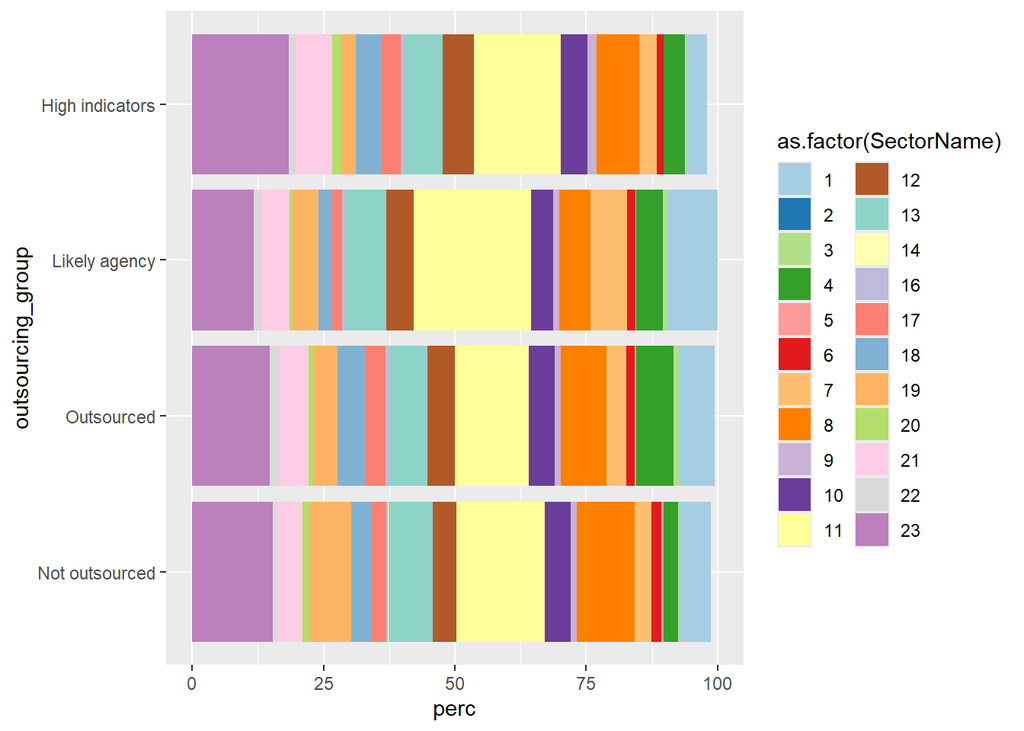

```r
plot_data <- sector_summary %>%
  drop_na(SectorName_labelled) %>%
  droplevels()

plot_data %>%
  ggplot(aes(outsourcing_group, perc, fill = as.factor(SectorName))) +
  geom_col() +
  coord_flip() +
  scale_fill_manual(values=many_colours)
```

```r
sector_key <- data.frame("number" = seq(1,length(unique(plot_data$SectorName)),1),
                            "Sector" = unique(plot_data$SectorName_labelled))

sector_key %>%
  kable() %>%
  kable_styling(full_width = F)
```

| number | Sector |
| --- | --- |
| 1 | ACCOMMODATION AND FOOD SERVICE ACTIVITIES |
| 2 | ACTIVITIES OF EXTRATERRITORIAL ORGANISATIONS AND BODIES |
| 3 | ACTIVITIES OF HOUSEHOLDS AS EMPLOYERS; UNDIFFERENTIATED GOODS-AND SERVICES-PRODUCING ACTIVITIES OF HOUSEHOLDS FOR OWN US |
| 4 | ADMINISTRATIVE AND SUPPORT SERVICE ACTIVITIES |
| 5 | AGRICULTURE, FORESTRY AND FISHING |
| 6 | ARTS, ENTERTAINMENT AND RECREATION |
| 7 | CONSTRUCTION |
| 8 | EDUCATION |
| 9 | ELECTRICITY, GAS, STEAM AND AIR CONDITIONING SUPPLY |
| 10 | FINANCIAL AND INSURANCE ACTIVITIES |
| 11 | HUMAN HEALTH AND SOCIAL WORK ACTIVITIES |
| 12 | INFORMATION AND COMMUNICATION |
| 13 | MANUFACTURING |
| 14 | MINING AND QUARRYING |
| 15 | Not found |
| 16 | OTHER SERVICE ACTIVITIES |
| 17 | PROFESSIONAL, SCIENTIFIC AND TECHNICAL ACTIVITIES |
| 18 | PUBLIC ADMINISTRATION AND DEFENCE; COMPULSORY SOCIAL SECURITY |
| 19 | REAL ESTATE ACTIVITIES |
| 20 | TRANSPORTATION AND STORAGE |
| 21 | WATER SUPPLY; SEWERAGE, WASTE MANAGEMENT AND REMEDIATION ACTIVITIES |
| 22 | WHOLESALE AND RETAIL TRADE; REPAIR OF MOTOR VEHICLES AND MOTORCYCLES |

```r
plot_data %>%
  select(outsourcing_group, SectorName, SectorName_labelled, perc) %>%
  group_by(outsourcing_group) %>%
  arrange(desc(perc), .by_group=TRUE) %>%
  kable() %>%
  kable_styling(full_width = F)
```

| outsourcing_group | SectorName | SectorName_labelled | perc |
| --- | --- | --- | --- |
| Not outsourced | 11 | HUMAN HEALTH AND SOCIAL WORK ACTIVITIES | 16.7360613 |
| Not outsourced | 23 | WHOLESALE AND RETAIL TRADE; REPAIR OF MOTOR VEHICLES AND MOTORCYCLES | 15.4267755 |
| Not outsourced | 8 | EDUCATION | 10.9976142 |
| Not outsourced | 13 | MANUFACTURING | 8.3872365 |
| Not outsourced | 19 | PUBLIC ADMINISTRATION AND DEFENCE; COMPULSORY SOCIAL SECURITY | 7.9832203 |
| Not outsourced | 1 | ACCOMMODATION AND FOOD SERVICE ACTIVITIES | 5.8872856 |
| Not outsourced | 10 | FINANCIAL AND INSURANCE ACTIVITIES | 4.9095444 |
| Not outsourced | 21 | TRANSPORTATION AND STORAGE | 4.8584753 |
| Not outsourced | 12 | INFORMATION AND COMMUNICATION | 4.5805150 |
| Not outsourced | 18 | PROFESSIONAL, SCIENTIFIC AND TECHNICAL ACTIVITIES | 3.9235934 |
| Not outsourced | 7 | CONSTRUCTION | 3.2214668 |
| Not outsourced | 17 | OTHER SERVICE ACTIVITIES | 2.7676269 |
| Not outsourced | 4 | ADMINISTRATIVE AND SUPPORT SERVICE ACTIVITIES | 2.7603460 |
| Not outsourced | 6 | ARTS, ENTERTAINMENT AND RECREATION | 1.8053220 |
| Not outsourced | 20 | REAL ESTATE ACTIVITIES | 1.2521925 |
| Not outsourced | 9 | ELECTRICITY, GAS, STEAM AND AIR CONDITIONING SUPPLY | 1.2117371 |
| Not outsourced | 22 | WATER SUPPLY; SEWERAGE, WASTE MANAGEMENT AND REMEDIATION ACTIVITIES | 0.7627515 |
| Not outsourced | 5 | AGRICULTURE, FORESTRY AND FISHING | 0.4225971 |
| Not outsourced | 3 | ACTIVITIES OF HOUSEHOLDS AS EMPLOYERS; UNDIFFERENTIATED GOODS-AND SERVICES-PRODUCING ACTIVITIES OF HOUSEHOLDS FOR OWN US | 0.3123761 |
| Not outsourced | 16 | Not found | 0.3030015 |
| Not outsourced | 14 | MINING AND QUARRYING | 0.1034233 |
| Not outsourced | 2 | ACTIVITIES OF EXTRATERRITORIAL ORGANISATIONS AND BODIES | 0.0431916 |
| Outsourced | 23 | WHOLESALE AND RETAIL TRADE; REPAIR OF MOTOR VEHICLES AND MOTORCYCLES | 14.8186202 |
| Outsourced | 11 | HUMAN HEALTH AND SOCIAL WORK ACTIVITIES | 14.1182403 |
| Outsourced | 8 | EDUCATION | 8.6944943 |
| Outsourced | 13 | MANUFACTURING | 7.1682245 |
| Outsourced | 4 | ADMINISTRATIVE AND SUPPORT SERVICE ACTIVITIES | 7.1400736 |
| Outsourced | 1 | ACCOMMODATION AND FOOD SERVICE ACTIVITIES | 6.7289225 |
| Outsourced | 21 | TRANSPORTATION AND STORAGE | 5.5518952 |
| Outsourced | 12 | INFORMATION AND COMMUNICATION | 5.2270278 |

[output cut: 51 more lines]

13/05 MORE TO DO HERE FOR SECTOR AS ABOVE

### Ethnicity

```r
ethnicity_statistics <- data %>%
  group_by(outsourcing_status, Ethnicity_labelled) %>%
  summarise(
    n = n(), # count cases
    Frequency = sum(NatRepemployees) # count weighted cases
  ) %>%
  mutate(
    N = sum(n),
    Sum = sum(Frequency),
    Percentage = 100 * (Frequency / Sum),
    Ethnicity_short = Ethnicity_labelled
  ) %>%
    separate_wider_delim(Ethnicity_short,
                         names = c("Ethnicity_short", "Ethnicity detail"),
                         delim = stringr::regex(" / |, "),  # use multiple delims
                         too_few = "align_start",
                         too_many = "merge")

readr::write_csv(ethnicity_statistics, file = "../outputs/data/ethnicity_stats_1.csv")
```

```r
ethnicities <- as.vector(unique(haven::as_factor(data$Ethnicity)))
non_white_ethnicities <- ethnicities[!(ethnicities %in% "English / Welsh / Scottish / Northern Irish / British")]


# Will throw NA warning. I think this OK but investigate how to avoid the problem
summary_table <- data %>%
  mutate(
    Ethnicity = haven::as_factor(Ethnicity)
  ) %>%
  mutate(
    Ethnicity = forcats::fct_collapse(as.character(Ethnicity),
                                      "White British" = c("English / Welsh / Scottish / Northern Irish / British"),
                                      "Non-White British" = non_white_ethnicities)
  ) %>%
  group_by(outsourcing_status, Ethnicity) %>%
  summarise(
    n = n()
  ) %>%
  mutate(
    Sum = sum(n),
    Percentage = 100 * (n / Sum)
  )

group_1 <- t(tibble("present"=summary_table[which(summary_table["Ethnicity"]=="White British" &
                                 summary_table["outsourcing_status"]=="Outsourced"),"n"],
"not present" = summary_table[which(summary_table["Ethnicity"]=="Non-White British" &
                                 summary_table["outsourcing_status"]=="Outsourced"),"n"]
))

group_2 <- t(tibble("present"=summary_table[which(summary_table["Ethnicity"]=="White British" &
                                 summary_table["outsourcing_status"]=="Not outsourced"),"n"],
"not present" = summary_table[which(summary_table["Ethnicity"]=="Non-White British" &
                                 summary_table["outsourcing_status"]=="Not outsourced"),"n"]
))


comp_mat <- as.matrix(cbind(group_2, group_1)) # matrix for crosstable
x2 <- gmodels::CrossTable(comp_mat, fisher=TRUE)
# `r if(x2[["chisq"]][["p.value"]] < .001, "< .001", paste0("= ", round(x2[["chisq"]][["p.value"]],2)))`).
# (chi-square = `r round(x2[["chisq"]][["statistic"]][["X-squared"]],2)`, *p* = `r round(x2[["chisq"]][["p.value"]],3)`).
```

Breaking down by ethnicity shows that the outsourced group has a lower proportion of White workers compared to the non-outsourced group. For example, in the outsourced group, the proportion of British (‘White’) workers is 66.91 %, compared to 78.01% in the not outsourced group. Needless to say, this means that there is a correspondingly higher proportion of workers from minority backgrounds in the outsourced group, notably from African (4.1%) and other White backgrounds (5.5, amongst others.[^12] These differences mean that **outsourced workers are 1.87 times more likely to be a member of minority ethnicity than non-outsourced workers.**

```r
ethnicity_statistics %>%
  # mutate(
  #   Ethnicity = haven::as_factor(Ethnicity)
  #   ) %>%
  knitr::kable(.,digits = 2) %>%
  kable_styling(full_width = F)
```

| outsourcing_status | Ethnicity_labelled | n | Frequency | N | Sum | Percentage | Ethnicity_short | Ethnicity detail |
| --- | --- | --- | --- | --- | --- | --- | --- | --- |
| Not outsourced | English / Welsh / Scottish / Northern Irish / British | 6623 | 6589.16 | 8472 | 8446.64 | 78.01 | English | Welsh / Scottish / Northern Irish / British |
| Not outsourced | Irish | 111 | 98.75 | 8472 | 8446.64 | 1.17 | Irish | NA |
| Not outsourced | Gypsy or Irish Traveller | 6 | 8.32 | 8472 | 8446.64 | 0.10 | Gypsy or Irish Traveller | NA |
| Not outsourced | Roma | 4 | 5.24 | 8472 | 8446.64 | 0.06 | Roma | NA |
| Not outsourced | Any other White background | 369 | 385.42 | 8472 | 8446.64 | 4.56 | Any other White background | NA |
| Not outsourced | White and Black Caribbean | 84 | 53.22 | 8472 | 8446.64 | 0.63 | White and Black Caribbean | NA |
| Not outsourced | White and Black African | 40 | 20.43 | 8472 | 8446.64 | 0.24 | White and Black African | NA |
| Not outsourced | White and Asian | 61 | 32.39 | 8472 | 8446.64 | 0.38 | White and Asian | NA |
| Not outsourced | Any other Mixed / Multiple ethnic background | 59 | 33.60 | 8472 | 8446.64 | 0.40 | Any other Mixed | Multiple ethnic background |
| Not outsourced | Indian | 170 | 237.76 | 8472 | 8446.64 | 2.81 | Indian | NA |
| Not outsourced | Pakistani | 93 | 96.09 | 8472 | 8446.64 | 1.14 | Pakistani | NA |
| Not outsourced | Bangladeshi | 47 | 53.46 | 8472 | 8446.64 | 0.63 | Bangladeshi | NA |
| Not outsourced | Chinese | 70 | 124.50 | 8472 | 8446.64 | 1.47 | Chinese | NA |
| Not outsourced | Any other Asian background | 57 | 118.35 | 8472 | 8446.64 | 1.40 | Any other Asian background | NA |
| Not outsourced | African | 232 | 157.09 | 8472 | 8446.64 | 1.86 | African | NA |
| Not outsourced | Caribbean | 74 | 56.56 | 8472 | 8446.64 | 0.67 | Caribbean | NA |
| Not outsourced | Any other Black, Black British, or Caribbean background | 36 | 25.60 | 8472 | 8446.64 | 0.30 | Any other Black | Black British, or Caribbean background |
| Not outsourced | Arab | 12 | 20.47 | 8472 | 8446.64 | 0.24 | Arab | NA |
| Not outsourced | Any other ethnic group | 13 | 23.40 | 8472 | 8446.64 | 0.28 | Any other ethnic group | NA |
| Not outsourced | Don’t think of myself as any of these | 7 | 5.87 | 8472 | 8446.64 | 0.07 | Don’t think of myself as any of these | NA |
| Not outsourced | Prefer not to say | 22 | 23.54 | 8472 | 8446.64 | 0.28 | Prefer not to say | NA |
| Not outsourced | NA | 282 | 277.44 | 8472 | 8446.64 | 3.28 | NA | NA |
| Outsourced | English / Welsh / Scottish / Northern Irish / British | 1124 | 1143.07 | 1683 | 1708.36 | 66.91 | English | Welsh / Scottish / Northern Irish / British |
| Outsourced | Irish | 17 | 14.86 | 1683 | 1708.36 | 0.87 | Irish | NA |
| Outsourced | Gypsy or Irish Traveller | 2 | 2.48 | 1683 | 1708.36 | 0.14 | Gypsy or Irish Traveller | NA |
| Outsourced | Roma | 3 | 2.25 | 1683 | 1708.36 | 0.13 | Roma | NA |
| Outsourced | Any other White background | 80 | 93.96 | 1683 | 1708.36 | 5.50 | Any other White background | NA |
| Outsourced | White and Black Caribbean | 11 | 5.53 | 1683 | 1708.36 | 0.32 | White and Black Caribbean | NA |
| Outsourced | White and Black African | 26 | 14.61 | 1683 | 1708.36 | 0.86 | White and Black African | NA |
| Outsourced | White and Asian | 12 | 9.13 | 1683 | 1708.36 | 0.53 | White and Asian | NA |
| Outsourced | Any other Mixed / Multiple ethnic background | 23 | 15.89 | 1683 | 1708.36 | 0.93 | Any other Mixed | Multiple ethnic background |
| Outsourced | Indian | 55 | 73.98 | 1683 | 1708.36 | 4.33 | Indian | NA |
| Outsourced | Pakistani | 49 | 53.85 | 1683 | 1708.36 | 3.15 | Pakistani | NA |
| Outsourced | Bangladeshi | 21 | 23.04 | 1683 | 1708.36 | 1.35 | Bangladeshi | NA |
| Outsourced | Chinese | 12 | 21.04 | 1683 | 1708.36 | 1.23 | Chinese | NA |
| Outsourced | Any other Asian background | 26 | 44.80 | 1683 | 1708.36 | 2.62 | Any other Asian background | NA |
| Outsourced | African | 111 | 69.96 | 1683 | 1708.36 | 4.10 | African | NA |
| Outsourced | Caribbean | 15 | 15.11 | 1683 | 1708.36 | 0.88 | Caribbean | NA |
| Outsourced | Any other Black, Black British, or Caribbean background | 16 | 11.79 | 1683 | 1708.36 | 0.69 | Any other Black | Black British, or Caribbean background |
| Outsourced | Arab | 7 | 12.03 | 1683 | 1708.36 | 0.70 | Arab | NA |
| Outsourced | Any other ethnic group | 3 | 7.06 | 1683 | 1708.36 | 0.41 | Any other ethnic group | NA |
| Outsourced | Don’t think of myself as any of these | 5 | 2.94 | 1683 | 1708.36 | 0.17 | Don’t think of myself as any of these | NA |
| Outsourced | Prefer not to say | 4 | 6.92 | 1683 | 1708.36 | 0.40 | Prefer not to say | NA |
| Outsourced | NA | 61 | 64.07 | 1683 | 1708.36 | 3.75 | NA | NA |

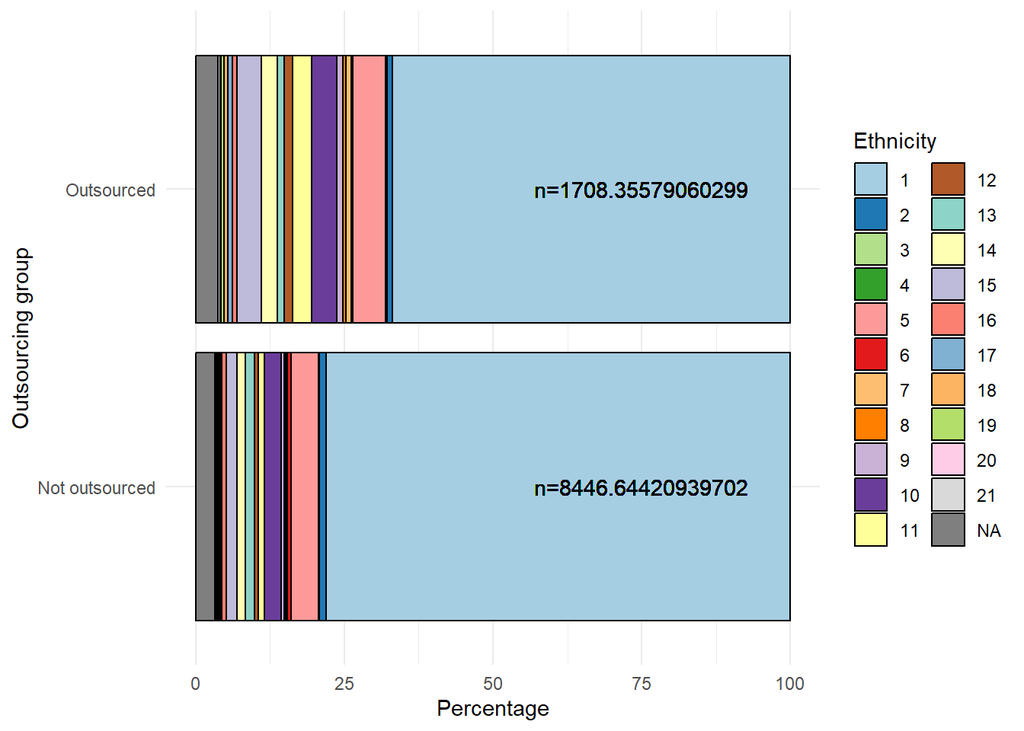

```r
data %>%
  # get values of labels
  # mutate_all(haven::as_factor) %>%
  group_by(outsourcing_status, Ethnicity) %>%
  summarise(
    Frequency = sum(NatRepemployees),
    n = n()
  ) %>%
  mutate(
    Sum = sum(Frequency),
    Percentage = 100 * (Frequency / Sum),
    N = n()
  ) %>%
  ggplot(., aes(outsourcing_status, Percentage, fill = as.factor(Ethnicity))) +
  geom_col(colour="black") +
  annotate("text", x = ethnicity_statistics$outsourcing_status, y = 75, label = paste0("n=",ethnicity_statistics$Sum)) +
  coord_flip() +
  scale_fill_manual(values = many_colours, name = "Ethnicity") +
  xlab("Outsourcing group") +
  theme_minimal()
```

```r
ethnicity_key <- data.frame("number" = seq(1,22,1),
                            "ethnicity" = c(levels(ethnicity_statistics$Ethnicity_labelled), NA))

ethnicity_key %>%
  kable() %>%
  kable_styling(full_width = F)
```

| number | ethnicity |
| --- | --- |
| 1 | English / Welsh / Scottish / Northern Irish / British |
| 2 | Irish |
| 3 | Gypsy or Irish Traveller |
| 4 | Roma |
| 5 | Any other White background |
| 6 | White and Black Caribbean |
| 7 | White and Black African |
| 8 | White and Asian |
| 9 | Any other Mixed / Multiple ethnic background |
| 10 | Indian |
| 11 | Pakistani |
| 12 | Bangladeshi |
| 13 | Chinese |
| 14 | Any other Asian background |
| 15 | African |
| 16 | Caribbean |
| 17 | Any other Black, Black British, or Caribbean background |
| 18 | Arab |
| 19 | Any other ethnic group |
| 20 | Don’t think of myself as any of these |
| 21 | Prefer not to say |
| 22 | NA |

```r
ethnicity_statistics_2 <- data %>%
  group_by(outsourcing_status, Ethnicity_collapsed) %>%
  summarise(
    n = n(), # count cases
    Frequency = sum(NatRepemployees) # count weighted cases
  ) %>%
  mutate(
    N = sum(n),
    Sum = sum(Frequency),
    Percentage = 100 * (Frequency / Sum)
  ) #%>%
    # separate_wider_delim(Ethnicity_short,
    #                      names = c("Ethnicity_short", "Ethnicity detail"),
    #                      delim = stringr::regex(" / |, "),  # use multiple delims
    #                      too_few = "align_start",
    #                      too_many = "merge")

#readr::write_csv(ethnicity_statistics, file = "../outputs/data/ethnicity_stats_2.csv")
```

```r
ethnicity_statistics_2 %>%
  # mutate(
  #   Ethnicity = haven::as_factor(Ethnicity)
  #   ) %>%
  knitr::kable(.,digits = 2) %>%
  kable_styling(full_width = F)
```

| outsourcing_status | Ethnicity_collapsed | n | Frequency | N | Sum | Percentage |
| --- | --- | --- | --- | --- | --- | --- |
| Not outsourced | White | 6734 | 6687.91 | 8472 | 8446.64 | 79.18 |
| Not outsourced | White other | 379 | 398.98 | 8472 | 8446.64 | 4.72 |
| Not outsourced | Black Caribbean | 158 | 109.78 | 8472 | 8446.64 | 1.30 |
| Not outsourced | Black African | 272 | 177.52 | 8472 | 8446.64 | 2.10 |
| Not outsourced | Mixed other | 120 | 65.99 | 8472 | 8446.64 | 0.78 |
| Not outsourced | South Asian | 310 | 387.30 | 8472 | 8446.64 | 4.59 |
| Not outsourced | East Asian | 70 | 124.50 | 8472 | 8446.64 | 1.47 |
| Not outsourced | Other | 381 | 448.60 | 8472 | 8446.64 | 5.31 |
| Not outsourced | Black other | 36 | 25.60 | 8472 | 8446.64 | 0.30 |
| Not outsourced | Arab | 12 | 20.47 | 8472 | 8446.64 | 0.24 |
| Outsourced | White | 1141 | 1157.93 | 1683 | 1708.36 | 67.78 |
| Outsourced | White other | 85 | 98.68 | 1683 | 1708.36 | 5.78 |
| Outsourced | Black Caribbean | 26 | 20.64 | 1683 | 1708.36 | 1.21 |
| Outsourced | Black African | 137 | 84.58 | 1683 | 1708.36 | 4.95 |
| Outsourced | Mixed other | 35 | 25.02 | 1683 | 1708.36 | 1.46 |
| Outsourced | South Asian | 125 | 150.87 | 1683 | 1708.36 | 8.83 |
| Outsourced | East Asian | 12 | 21.04 | 1683 | 1708.36 | 1.23 |
| Outsourced | Other | 99 | 125.78 | 1683 | 1708.36 | 7.36 |
| Outsourced | Black other | 16 | 11.79 | 1683 | 1708.36 | 0.69 |
| Outsourced | Arab | 7 | 12.03 | 1683 | 1708.36 | 0.70 |

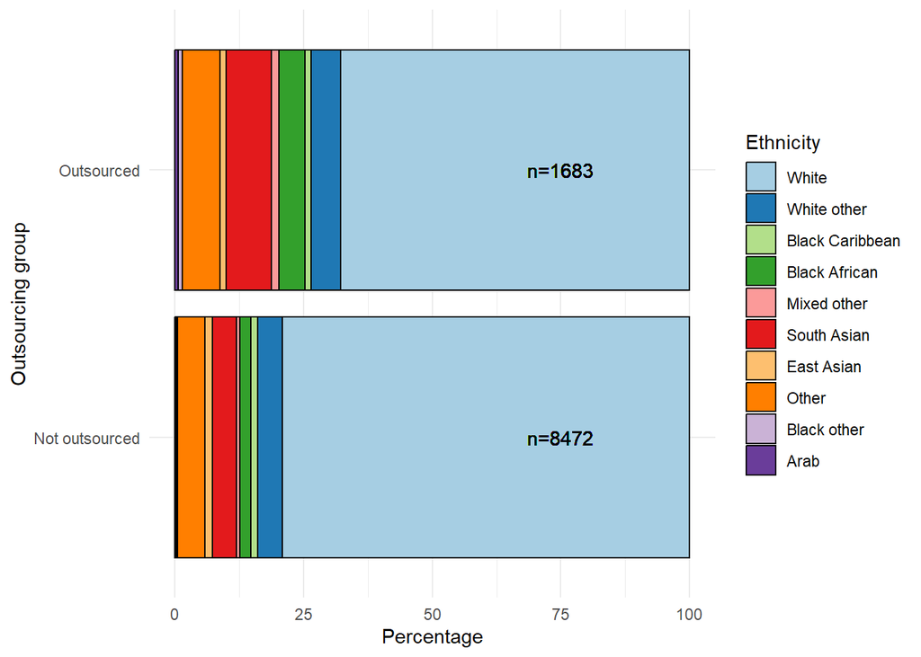

```r
data %>%
  # get values of labels
  # mutate_all(haven::as_factor) %>%
  group_by(outsourcing_status, Ethnicity_collapsed) %>%
  summarise(
    Frequency = sum(NatRepemployees),
    n = n()
  ) %>%
  mutate(
    Sum = sum(Frequency),
    Percentage = 100 * (Frequency / Sum),
    N = n()
  ) %>%
  ggplot(., aes(outsourcing_status, Percentage, fill = Ethnicity_collapsed)) +
  geom_col(colour="black") +
  annotate("text", x = ethnicity_statistics$outsourcing_status, y = 75, label = paste0("n=",ethnicity_statistics$N)) +
  coord_flip() +
  scale_fill_manual(values = many_colours, name = "Ethnicity") +
  xlab("Outsourcing group") +
  theme_minimal()
```

```r
mod <- glm(outsourcing_status ~ Ethnicity_collapsed, data, family="binomial", weights=NatRepemployees)
summary(mod)
```

```
Call:
glm(formula = outsourcing_status ~ Ethnicity_collapsed, family = "binomial",
    data = data, weights = NatRepemployees)

Coefficients:
                                   Estimate Std. Error z value Pr(>|z|)
(Intercept)                        -1.75366    0.03183 -55.095  < 2e-16 ***
Ethnicity_collapsedWhite other      0.35669    0.11685   3.053 0.002268 **
Ethnicity_collapsedBlack Caribbean  0.08232    0.24203   0.340 0.733754
Ethnicity_collapsedBlack African    1.01225    0.13590   7.448 9.45e-14 ***
Ethnicity_collapsedMixed other      0.78383    0.23693   3.308 0.000939 ***
Ethnicity_collapsedSouth Asian      0.81086    0.10111   8.020 1.06e-15 ***
Ethnicity_collapsedEast Asian      -0.02436    0.23787  -0.102 0.918417
Ethnicity_collapsedOther            0.48211    0.10579   4.557 5.19e-06 ***
Ethnicity_collapsedBlack other      0.97803    0.35344   2.767 0.005655 **
Ethnicity_collapsedArab             1.22173    0.36469   3.350 0.000808 ***
---
Signif. codes:  0 '***' 0.001 '**' 0.01 '*' 0.05 '.' 0.1 ' ' 1

(Dispersion parameter for binomial family taken to be 1)

    Null deviance: 9201.8  on 10154  degrees of freedom
Residual deviance: 9065.3  on 10145  degrees of freedom
AIC: 10088

Number of Fisher Scoring iterations: 4
```

```r
coef_table <- data.frame("estimate" = mod[["coefficients"]]) %>%
  mutate(
    or = round(exp(estimate),2)
  )
```

Comparison of ethnicities indicates that some groups are statistically more likely to be outsourced than others

- Black African workers are 2.75 times more likely than White workers to be outsourced.
- Mixed other workers are 2.19 times more likely than White workers to be outsourced.
- South Asian workers are 2.25 times more likely than White workers to be outsourced.
- Other workers are 1.62 times more likely than White workers to be outsourced.
- Black other workers are 2.66 times more likely than White workers to be outsourced.
- Arab workers are 3.39 times more likely than White workers to be outsourced.

#### Paysplit[^13]

```r
ethnicity_summary_paysplit <- data %>%
  group_by(outsourcing_status, income_group, Ethnicity_labelled) %>%
  summarise(
    n = n(),
    Frequency = sum(NatRepemployees)
  ) %>%
  mutate(
    N = sum(n),
    Sum = sum(Frequency),
    Percentage = 100 * (Frequency / Sum),
    Ethnicity_short = Ethnicity_labelled
  ) %>%
    separate_wider_delim(Ethnicity_short,
                         names = c("Ethnicity_short", "Ethnicity detail"),
                         delim = stringr::regex(" / |, "),  # use multiple delims
                         too_few = "align_start",
                         too_many = "merge")

readr::write_csv(ethnicity_statistics, file = "../outputs/data/ethnicity_stats_paysplit_1.csv")
```

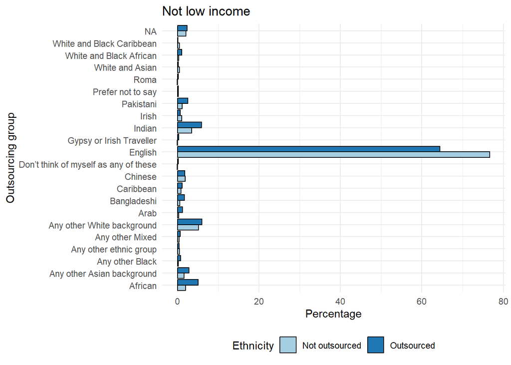

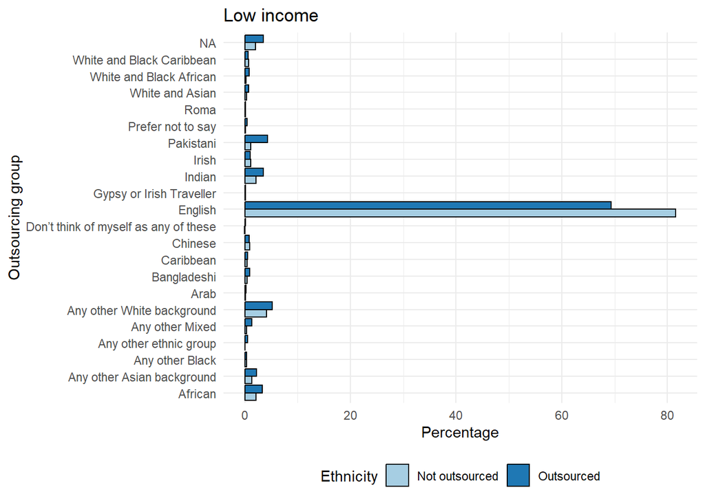

```r
temp_data <-  ethnicity_summary_paysplit %>%
  drop_na(income_group)

for(group in unique(temp_data$income_group)){
  plot_data <- temp_data %>%
    filter(income_group==group)

  plot <- plot_data %>%
    ggplot(., aes(Ethnicity_short, Percentage, fill = outsourcing_status)) +
      geom_col(colour="black", position = position_dodge()) +
      #annotate("text", x = ethnicity_statistics$outsourcing_status, y = 75, label = paste0("n=",ethnicity_statistics$Sum)) +
      coord_flip() +
      scale_fill_manual(values = many_colours, name = "Ethnicity") +
      xlab("Outsourcing group") +
      theme_minimal() +
    theme(
      legend.position = "bottom"
    ) +
    ggtitle(paste0(group, " income"))


  print(plot)
}
```

```r
# ethnicity_summary_paysplit %>%
#   drop_na(income_group) %>%
#   ggplot(., aes(outsourcing_status, Percentage, fill = Ethnicity_short)) +
#   facet_grid(rows=~income_group) +
#   geom_col(colour="black") +
#   #annotate("text", x = ethnicity_statistics$outsourcing_status, y = 75, label = paste0("n=",ethnicity_statistics$Sum)) +
#   coord_flip() +
#   scale_fill_manual(values = many_colours, name = "Ethnicity") +
#   xlab("Outsourcing group") +
#   theme_minimal() +
#   theme(
#     legend.position = "bottom"
#   )
```

```r
ethnicity_summary_paysplit <- data %>%
  group_by(outsourcing_status, income_group, Ethnicity_collapsed) %>%
  summarise(
    n = n(),
    Frequency = sum(NatRepemployees)
  ) %>%
  mutate(
    N = sum(n),
    Sum = sum(Frequency),
    Percentage = 100 * (Frequency / Sum)
  )

#readr::write_csv(ethnicity_statistics, file = "../outputs/data/ethnicity_stats_paysplit_1.csv")
```

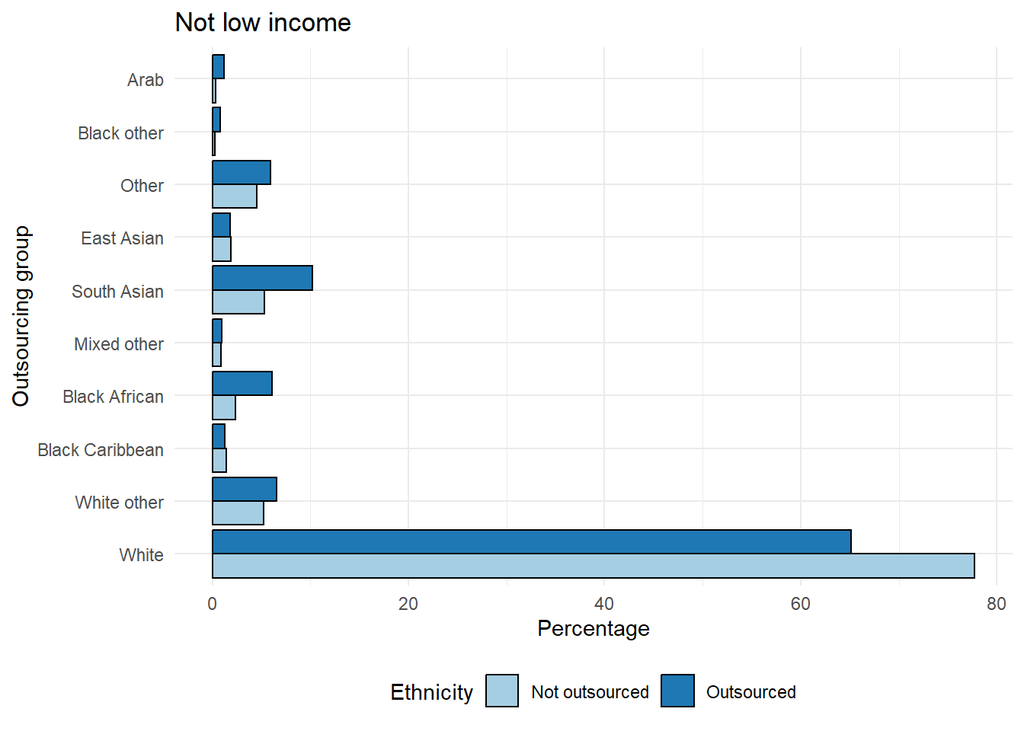

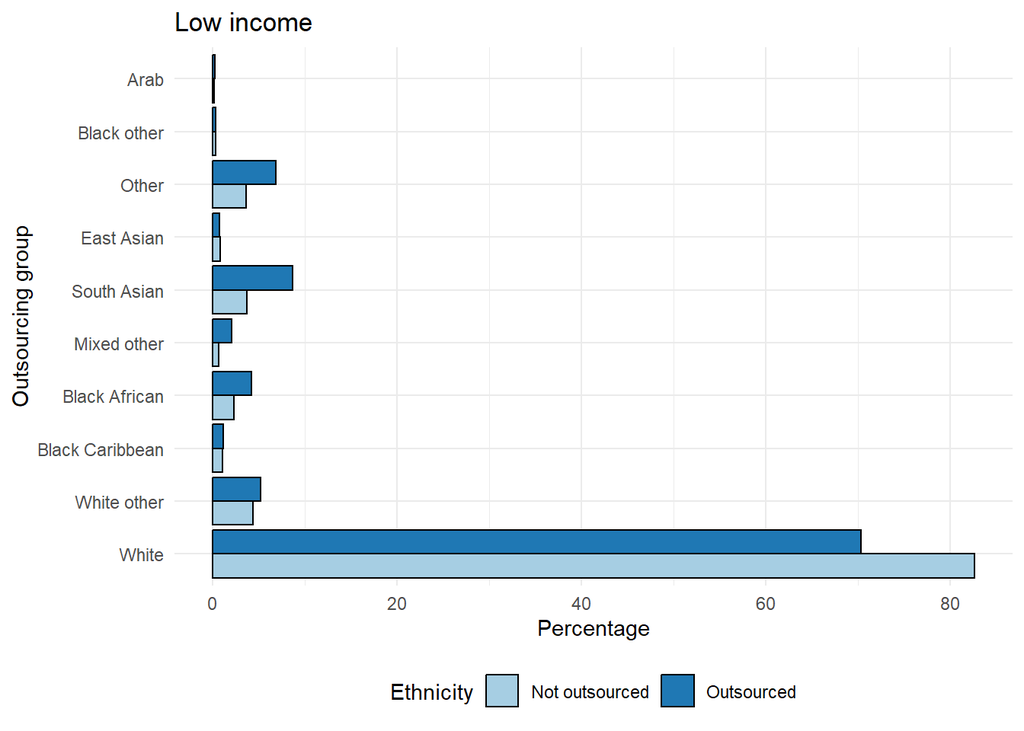

```r
temp_data <-  ethnicity_summary_paysplit %>%
  drop_na(income_group)

for(group in unique(temp_data$income_group)){
  plot_data <- temp_data %>%
    filter(income_group==group)

  plot <- plot_data %>%
    ggplot(., aes(Ethnicity_collapsed, Percentage, fill = outsourcing_status)) +
      geom_col(colour="black", position = position_dodge()) +
      #annotate("text", x = ethnicity_statistics$outsourcing_status, y = 75, label = paste0("n=",ethnicity_statistics$Sum)) +
      coord_flip() +
      scale_fill_manual(values = many_colours, name = "Ethnicity") +
      xlab("Outsourcing group") +
      theme_minimal() +
    theme(
      legend.position = "bottom"
    ) +
    ggtitle(paste0(group, " income"))


  print(plot)
}
```

```r
# ethnicity_summary_paysplit %>%
#   drop_na(income_group) %>%
#   ggplot(., aes(outsourcing_status, Percentage, fill = Ethnicity_short)) +
#   facet_grid(rows=~income_group) +
#   geom_col(colour="black") +
#   #annotate("text", x = ethnicity_statistics$outsourcing_status, y = 75, label = paste0("n=",ethnicity_statistics$Sum)) +
#   coord_flip() +
#   scale_fill_manual(values = many_colours, name = "Ethnicity") +
#   xlab("Outsourcing group") +
#   theme_minimal() +
#   theme(
#     legend.position = "bottom"
#   )
```

```r
mod <- glm(outsourcing_status ~ income_group*Ethnicity_collapsed, data, family="binomial")
summary(mod)
```

```
Call:
glm(formula = outsourcing_status ~ income_group * Ethnicity_collapsed,
    family = "binomial", data = data)

Coefficients:
                                                   Estimate Std. Error z value
(Intercept)                                        -1.83224    0.04438 -41.286
income_groupLow                                     0.17246    0.06883   2.506
Ethnicity_collapsedWhite other                      0.33035    0.16107   2.051
Ethnicity_collapsedBlack Caribbean                 -0.19371    0.31031  -0.624
Ethnicity_collapsedBlack African                    1.23328    0.13921   8.859
Ethnicity_collapsedMixed other                      0.23623    0.28662   0.824
Ethnicity_collapsedSouth Asian                      0.92653    0.14299   6.480
Ethnicity_collapsedEast Asian                       0.17932    0.36655   0.489
Ethnicity_collapsedOther                            0.42737    0.18195   2.349
Ethnicity_collapsedBlack other                      1.19039    0.39319   3.027
Ethnicity_collapsedArab                             1.32142    0.51830   2.550
income_groupLow:Ethnicity_collapsedWhite other     -0.13691    0.27257  -0.502
income_groupLow:Ethnicity_collapsedBlack Caribbean  0.55421    0.45290   1.224
income_groupLow:Ethnicity_collapsedBlack African   -0.44101    0.23655  -1.864
income_groupLow:Ethnicity_collapsedMixed other      0.64585    0.41324   1.563
income_groupLow:Ethnicity_collapsedSouth Asian     -0.01517    0.23811  -0.064
income_groupLow:Ethnicity_collapsedEast Asian      -0.12898    0.73289  -0.176
income_groupLow:Ethnicity_collapsedOther            0.33341    0.27581   1.209
income_groupLow:Ethnicity_collapsedBlack other     -0.70927    0.69591  -1.019
income_groupLow:Ethnicity_collapsedArab            -0.35479    1.33094  -0.267
                                                   Pr(>|z|)
(Intercept)                                         < 2e-16 ***
income_groupLow                                     0.01222 *
Ethnicity_collapsedWhite other                      0.04027 *
Ethnicity_collapsedBlack Caribbean                  0.53246
Ethnicity_collapsedBlack African                    < 2e-16 ***
Ethnicity_collapsedMixed other                      0.40983
Ethnicity_collapsedSouth Asian                     9.19e-11 ***
Ethnicity_collapsedEast Asian                       0.62469
Ethnicity_collapsedOther                            0.01883 *
Ethnicity_collapsedBlack other                      0.00247 **
Ethnicity_collapsedArab                             0.01079 *
income_groupLow:Ethnicity_collapsedWhite other      0.61548
income_groupLow:Ethnicity_collapsedBlack Caribbean  0.22107
income_groupLow:Ethnicity_collapsedBlack African    0.06228 .
income_groupLow:Ethnicity_collapsedMixed other      0.11808
income_groupLow:Ethnicity_collapsedSouth Asian      0.94921
income_groupLow:Ethnicity_collapsedEast Asian       0.86030
income_groupLow:Ethnicity_collapsedOther            0.22673
income_groupLow:Ethnicity_collapsedBlack other      0.30811
income_groupLow:Ethnicity_collapsedArab             0.78980
---
Signif. codes:  0 '***' 0.001 '**' 0.01 '*' 0.05 '.' 0.1 ' ' 1

(Dispersion parameter for binomial family taken to be 1)

    Null deviance: 8127.6  on 8942  degrees of freedom
Residual deviance: 7956.9  on 8923  degrees of freedom
  (1212 observations deleted due to missingness)
AIC: 7996.9

Number of Fisher Scoring iterations: 4
```

```r
test_data <- data %>%
  drop_na(income_group) %>%
  mutate(
    income_group = factor(income_group, levels = c("Not low", "Low")),
    Ethnicity_short = Ethnicity_labelled
  ) %>%
  separate_wider_delim(Ethnicity_short,
                       names = c("Ethnicity_short", "Ethnicity detail"),
                       delim = " / ",
                       too_few = "align_start",
                       too_many = "merge") %>%
  mutate(
    Ethnicity_short = forcats::fct_relevel(factor(Ethnicity_short), "English")
  )


test <- glm(outsourcing_status ~ Age + Gender + income_group + Ethnicity_short, family = "binomial", data = test_data)
summary(test)
```

```
Call:
glm(formula = outsourcing_status ~ Age + Gender + income_group +
    Ethnicity_short, family = "binomial", data = test_data)

Coefficients:
                                                                        Estimate
(Intercept)                                                            -1.122623
Age                                                                    -0.024661
GenderMale                                                              0.531731
GenderOther                                                             0.128987
GenderPrefer not to say                                                -0.240452
income_groupLow                                                         0.276827
Ethnicity_shortAfrican                                                  0.750804
Ethnicity_shortAny other Asian background                               0.691922
Ethnicity_shortAny other Black, Black British, or Caribbean background  0.752002
Ethnicity_shortAny other ethnic group                                   0.220800
Ethnicity_shortAny other Mixed                                          0.673451
Ethnicity_shortAny other White background                               0.171750
Ethnicity_shortArab                                                     0.989803
Ethnicity_shortBangladeshi                                              0.703248
Ethnicity_shortCaribbean                                                0.183752
Ethnicity_shortChinese                                                  0.021374
Ethnicity_shortDon’t think of myself as any of these                    1.449163
Ethnicity_shortGypsy or Irish Traveller                                 0.282974
Ethnicity_shortIndian                                                   0.548848
Ethnicity_shortIrish                                                   -0.126226
Ethnicity_shortPakistani                                                0.864916
Ethnicity_shortPrefer not to say                                       -0.006321
Ethnicity_shortRoma                                                     1.082635
Ethnicity_shortWhite and Asian                                         -0.090237
Ethnicity_shortWhite and Black African                                  1.155726
Ethnicity_shortWhite and Black Caribbean                               -0.279236
                                                                       Std. Error
(Intercept)                                                              0.111181
Age                                                                      0.002392
GenderMale                                                               0.061348
GenderOther                                                              0.780590
GenderPrefer not to say                                                  1.056849
income_groupLow                                                          0.061893
Ethnicity_shortAfrican                                                   0.125846
```

[output cut: 96 more lines]

```
Ethnicity_shortRoma
Ethnicity_shortWhite and Asian
Ethnicity_shortWhite and Black African                                 ***
Ethnicity_shortWhite and Black Caribbean
---
Signif. codes:  0 '***' 0.001 '**' 0.01 '*' 0.05 '.' 0.1 ' ' 1

(Dispersion parameter for binomial family taken to be 1)

    Null deviance: 7918.6  on 8739  degrees of freedom
Residual deviance: 7567.2  on 8714  degrees of freedom
  (203 observations deleted due to missingness)
AIC: 7619.2

Number of Fisher Scoring iterations: 4
```

Another way of looking at this is to calculate, for each ethnicity, the proportion of workers in each outsourcing group. Doing so yields the plot below.[^14]

```r
ethnicity_statistics <- data %>%
  # get values of labels
  # mutate_all(haven::as_factor) %>%
  group_by(Ethnicity, outsourcing_status) %>%
  summarise(
    Frequency = n()
  ) %>%
  mutate(
    Sum = sum(Frequency),
    Percentage = 100 * (Frequency / Sum)
  ) %>%
  rename(
    `Outsourcing group` = outsourcing_status
  )

ethnicity_statistics %>%
  mutate(
    Ethnicity = haven::as_factor(Ethnicity)
    ) %>%
  knitr::kable(.,digits = 2) %>%
  kable_styling(full_width = F)
```

| Ethnicity | Outsourcing group | Frequency | Sum | Percentage |
| --- | --- | --- | --- | --- |
| English / Welsh / Scottish / Northern Irish / British | Not outsourced | 6623 | 7747 | 85.49 |
| English / Welsh / Scottish / Northern Irish / British | Outsourced | 1124 | 7747 | 14.51 |
| Irish | Not outsourced | 111 | 128 | 86.72 |
| Irish | Outsourced | 17 | 128 | 13.28 |
| Gypsy or Irish Traveller | Not outsourced | 6 | 8 | 75.00 |
| Gypsy or Irish Traveller | Outsourced | 2 | 8 | 25.00 |
| Roma | Not outsourced | 4 | 7 | 57.14 |
| Roma | Outsourced | 3 | 7 | 42.86 |
| Any other White background | Not outsourced | 369 | 449 | 82.18 |
| Any other White background | Outsourced | 80 | 449 | 17.82 |
| White and Black Caribbean | Not outsourced | 84 | 95 | 88.42 |
| White and Black Caribbean | Outsourced | 11 | 95 | 11.58 |
| White and Black African | Not outsourced | 40 | 66 | 60.61 |
| White and Black African | Outsourced | 26 | 66 | 39.39 |
| White and Asian | Not outsourced | 61 | 73 | 83.56 |
| White and Asian | Outsourced | 12 | 73 | 16.44 |
| Any other Mixed / Multiple ethnic background | Not outsourced | 59 | 82 | 71.95 |
| Any other Mixed / Multiple ethnic background | Outsourced | 23 | 82 | 28.05 |
| Indian | Not outsourced | 170 | 225 | 75.56 |
| Indian | Outsourced | 55 | 225 | 24.44 |
| Pakistani | Not outsourced | 93 | 142 | 65.49 |
| Pakistani | Outsourced | 49 | 142 | 34.51 |
| Bangladeshi | Not outsourced | 47 | 68 | 69.12 |
| Bangladeshi | Outsourced | 21 | 68 | 30.88 |
| Chinese | Not outsourced | 70 | 82 | 85.37 |
| Chinese | Outsourced | 12 | 82 | 14.63 |
| Any other Asian background | Not outsourced | 57 | 83 | 68.67 |
| Any other Asian background | Outsourced | 26 | 83 | 31.33 |
| African | Not outsourced | 232 | 343 | 67.64 |
| African | Outsourced | 111 | 343 | 32.36 |
| Caribbean | Not outsourced | 74 | 89 | 83.15 |
| Caribbean | Outsourced | 15 | 89 | 16.85 |
| Any other Black, Black British, or Caribbean background | Not outsourced | 36 | 52 | 69.23 |
| Any other Black, Black British, or Caribbean background | Outsourced | 16 | 52 | 30.77 |
| Arab | Not outsourced | 12 | 19 | 63.16 |
| Arab | Outsourced | 7 | 19 | 36.84 |
| Any other ethnic group | Not outsourced | 13 | 16 | 81.25 |
| Any other ethnic group | Outsourced | 3 | 16 | 18.75 |
| Don’t think of myself as any of these | Not outsourced | 7 | 12 | 58.33 |
| Don’t think of myself as any of these | Outsourced | 5 | 12 | 41.67 |
| Prefer not to say | Not outsourced | 22 | 26 | 84.62 |
| Prefer not to say | Outsourced | 4 | 26 | 15.38 |
| NA | Not outsourced | 282 | 343 | 82.22 |
| NA | Outsourced | 61 | 343 | 17.78 |

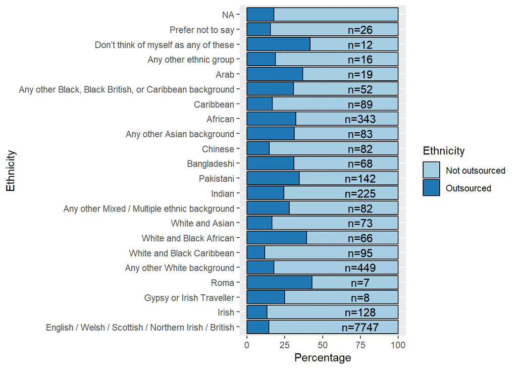

```r
# ordering_df <- ethnicity_statistics %>%
#   filter(`Outsourcing group` == "Outsourced") %>%
#   mutate(
#     Ethnicity = haven::as_factor(Ethnicity),
#     Ethnicity = factor(Ethnicity),
#     Ethnicity = forcats::fct_reorder(Ethnicity, Percentage)
#   )

ethnicity_statistics %>%
  mutate(
    Ethnicity = haven::as_factor(Ethnicity)
    ) %>%
  ggplot(., aes(Ethnicity, Percentage, fill = `Outsourcing group`)) +
  geom_col(colour="black") +
  annotate("text", x = ethnicity_statistics$Ethnicity, y = 75, label = paste0("n=", ethnicity_statistics$Sum)) +
  coord_flip() +
  scale_fill_manual(values=many_colours, name = "Ethnicity")
```

```r
write_csv(ethnicity_statistics, file="../outputs/data/ethnicity_stats_2.csv")
```

### Ethnicity repeat: Outsourcing groups

```r
ethnicity_statistics <- data %>%
  group_by(outsourcing_group, Ethnicity_labelled) %>%
  summarise(
    n = n(), # count cases
    Frequency = sum(NatRepemployees) # count weighted cases
  ) %>%
  mutate(
    N = sum(n),
    Sum = sum(Frequency),
    Percentage = 100 * (Frequency / Sum),
    Ethnicity_short = Ethnicity_labelled
  ) %>%
    separate_wider_delim(Ethnicity_short,
                         names = c("Ethnicity_short", "Ethnicity detail"),
                         delim = stringr::regex(" / |, "),  # use multiple delims
                         too_few = "align_start",
                         too_many = "merge")

readr::write_csv(ethnicity_statistics, file = "../outputs/data/ethnicity_stats_outsourcing_groups_1.csv")
```

```r
# test <- multinom(outsourcing_group ~ Ethnicity_collapsed, data, weights = NatRepemployees)
# summary(test)
#
# z <- summary(test)$coefficients/summary(test)$standard.errors
# z
#
# p <- (1 - pnorm(abs(z), 0, 1)) * 2
# p
#
# # Assuming your dataframe is named 'p'
# p_2 <- apply(p, 2, function(x) ifelse(x < 0.01, 1, NA))
#
# sig_ors <- exp(summary(test)$coefficients * p_2)

# we can take the results of this forward and plot the ors
```

```r
ethnicity_statistics %>%
  # mutate(
  #   Ethnicity = haven::as_factor(Ethnicity)
  #   ) %>%
  knitr::kable(.,digits = 2) %>%
  kable_styling(full_width = F)
```

| outsourcing_group | Ethnicity_labelled | n | Frequency | N | Sum | Percentage | Ethnicity_short | Ethnicity detail |
| --- | --- | --- | --- | --- | --- | --- | --- | --- |
| Not outsourced | English / Welsh / Scottish / Northern Irish / British | 6623 | 6589.16 | 8472 | 8446.64 | 78.01 | English | Welsh / Scottish / Northern Irish / British |
| Not outsourced | Irish | 111 | 98.75 | 8472 | 8446.64 | 1.17 | Irish | NA |
| Not outsourced | Gypsy or Irish Traveller | 6 | 8.32 | 8472 | 8446.64 | 0.10 | Gypsy or Irish Traveller | NA |
| Not outsourced | Roma | 4 | 5.24 | 8472 | 8446.64 | 0.06 | Roma | NA |
| Not outsourced | Any other White background | 369 | 385.42 | 8472 | 8446.64 | 4.56 | Any other White background | NA |
| Not outsourced | White and Black Caribbean | 84 | 53.22 | 8472 | 8446.64 | 0.63 | White and Black Caribbean | NA |
| Not outsourced | White and Black African | 40 | 20.43 | 8472 | 8446.64 | 0.24 | White and Black African | NA |
| Not outsourced | White and Asian | 61 | 32.39 | 8472 | 8446.64 | 0.38 | White and Asian | NA |
| Not outsourced | Any other Mixed / Multiple ethnic background | 59 | 33.60 | 8472 | 8446.64 | 0.40 | Any other Mixed | Multiple ethnic background |
| Not outsourced | Indian | 170 | 237.76 | 8472 | 8446.64 | 2.81 | Indian | NA |
| Not outsourced | Pakistani | 93 | 96.09 | 8472 | 8446.64 | 1.14 | Pakistani | NA |
| Not outsourced | Bangladeshi | 47 | 53.46 | 8472 | 8446.64 | 0.63 | Bangladeshi | NA |
| Not outsourced | Chinese | 70 | 124.50 | 8472 | 8446.64 | 1.47 | Chinese | NA |
| Not outsourced | Any other Asian background | 57 | 118.35 | 8472 | 8446.64 | 1.40 | Any other Asian background | NA |
| Not outsourced | African | 232 | 157.09 | 8472 | 8446.64 | 1.86 | African | NA |
| Not outsourced | Caribbean | 74 | 56.56 | 8472 | 8446.64 | 0.67 | Caribbean | NA |
| Not outsourced | Any other Black, Black British, or Caribbean background | 36 | 25.60 | 8472 | 8446.64 | 0.30 | Any other Black | Black British, or Caribbean background |
| Not outsourced | Arab | 12 | 20.47 | 8472 | 8446.64 | 0.24 | Arab | NA |
| Not outsourced | Any other ethnic group | 13 | 23.40 | 8472 | 8446.64 | 0.28 | Any other ethnic group | NA |
| Not outsourced | Don’t think of myself as any of these | 7 | 5.87 | 8472 | 8446.64 | 0.07 | Don’t think of myself as any of these | NA |
| Not outsourced | Prefer not to say | 22 | 23.54 | 8472 | 8446.64 | 0.28 | Prefer not to say | NA |
| Not outsourced | NA | 282 | 277.44 | 8472 | 8446.64 | 3.28 | NA | NA |
| Outsourced | English / Welsh / Scottish / Northern Irish / British | 742 | 778.19 | 1123 | 1161.08 | 67.02 | English | Welsh / Scottish / Northern Irish / British |
| Outsourced | Irish | 12 | 11.23 | 1123 | 1161.08 | 0.97 | Irish | NA |
| Outsourced | Gypsy or Irish Traveller | 2 | 2.48 | 1123 | 1161.08 | 0.21 | Gypsy or Irish Traveller | NA |
| Outsourced | Roma | 2 | 1.48 | 1123 | 1161.08 | 0.13 | Roma | NA |
| Outsourced | Any other White background | 63 | 72.25 | 1123 | 1161.08 | 6.22 | Any other White background | NA |
| Outsourced | White and Black Caribbean | 8 | 3.87 | 1123 | 1161.08 | 0.33 | White and Black Caribbean | NA |
| Outsourced | White and Black African | 21 | 11.08 | 1123 | 1161.08 | 0.95 | White and Black African | NA |
| Outsourced | White and Asian | 9 | 5.80 | 1123 | 1161.08 | 0.50 | White and Asian | NA |

[output cut: 54 more lines]

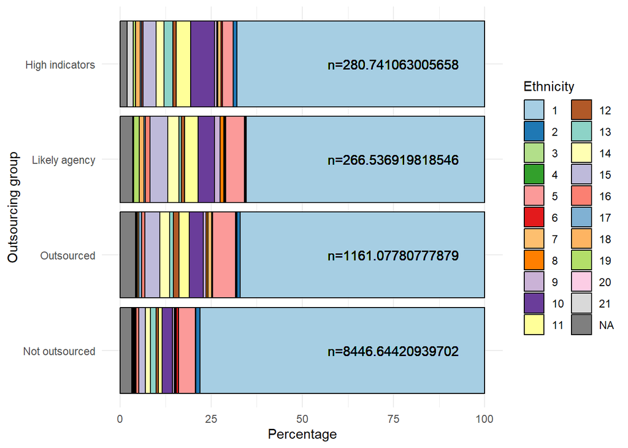

```r
data %>%
  # get values of labels
  # mutate_all(haven::as_factor) %>%
  group_by(outsourcing_group, Ethnicity) %>%
  summarise(
    Frequency = sum(NatRepemployees),
    n = n()
  ) %>%
  mutate(
    Sum = sum(Frequency),
    Percentage = 100 * (Frequency / Sum),
    N = n()
  ) %>%
  ggplot(., aes(outsourcing_group, Percentage, fill = as.factor(Ethnicity))) +
  geom_col(colour="black") +
  annotate("text", x = ethnicity_statistics$outsourcing_group, y = 75, label = paste0("n=",ethnicity_statistics$Sum)) +
  coord_flip() +
  scale_fill_manual(values = many_colours, name = "Ethnicity") +
  xlab("Outsourcing group") +
  theme_minimal()
```

```r
ethnicity_key <- data.frame("number" = seq(1,22,1),
                            "ethnicity" = c(levels(ethnicity_statistics$Ethnicity_labelled), NA))

ethnicity_key %>%
  kable() %>%
  kable_styling(full_width = F)
```

| number | ethnicity |
| --- | --- |
| 1 | English / Welsh / Scottish / Northern Irish / British |
| 2 | Irish |
| 3 | Gypsy or Irish Traveller |
| 4 | Roma |
| 5 | Any other White background |
| 6 | White and Black Caribbean |
| 7 | White and Black African |
| 8 | White and Asian |
| 9 | Any other Mixed / Multiple ethnic background |
| 10 | Indian |
| 11 | Pakistani |
| 12 | Bangladeshi |
| 13 | Chinese |
| 14 | Any other Asian background |
| 15 | African |
| 16 | Caribbean |
| 17 | Any other Black, Black British, or Caribbean background |
| 18 | Arab |
| 19 | Any other ethnic group |
| 20 | Don’t think of myself as any of these |
| 21 | Prefer not to say |
| 22 | NA |

```r
ethnicity_statistics_2 <- data %>%
  group_by(outsourcing_group, Ethnicity_collapsed) %>%
  summarise(
    n = n(), # count cases
    Frequency = sum(NatRepemployees) # count weighted cases
  ) %>%
  mutate(
    N = sum(n),
    Sum = sum(Frequency),
    Percentage = 100 * (Frequency / Sum)
  ) #%>%
    # separate_wider_delim(Ethnicity_short,
    #                      names = c("Ethnicity_short", "Ethnicity detail"),
    #                      delim = stringr::regex(" / |, "),  # use multiple delims
    #                      too_few = "align_start",
    #                      too_many = "merge")

#readr::write_csv(ethnicity_statistics, file = "../outputs/data/ethnicity_stats_2.csv")
```

```r
ethnicity_statistics_2 %>%
  # mutate(
  #   Ethnicity = haven::as_factor(Ethnicity)
  #   ) %>%
  knitr::kable(.,digits = 2) %>%
  kable_styling(full_width = F)
```

| outsourcing_group | Ethnicity_collapsed | n | Frequency | N | Sum | Percentage |
| --- | --- | --- | --- | --- | --- | --- |
| Not outsourced | White | 6734 | 6687.91 | 8472 | 8446.64 | 79.18 |
| Not outsourced | White other | 379 | 398.98 | 8472 | 8446.64 | 4.72 |
| Not outsourced | Black Caribbean | 158 | 109.78 | 8472 | 8446.64 | 1.30 |
| Not outsourced | Black African | 272 | 177.52 | 8472 | 8446.64 | 2.10 |
| Not outsourced | Mixed other | 120 | 65.99 | 8472 | 8446.64 | 0.78 |
| Not outsourced | South Asian | 310 | 387.30 | 8472 | 8446.64 | 4.59 |
| Not outsourced | East Asian | 70 | 124.50 | 8472 | 8446.64 | 1.47 |
| Not outsourced | Other | 381 | 448.60 | 8472 | 8446.64 | 5.31 |
| Not outsourced | Black other | 36 | 25.60 | 8472 | 8446.64 | 0.30 |
| Not outsourced | Arab | 12 | 20.47 | 8472 | 8446.64 | 0.24 |
| Outsourced | White | 754 | 789.42 | 1123 | 1161.08 | 67.99 |
| Outsourced | White other | 67 | 76.21 | 1123 | 1161.08 | 6.56 |
| Outsourced | Black Caribbean | 18 | 14.27 | 1123 | 1161.08 | 1.23 |
| Outsourced | Black African | 95 | 58.28 | 1123 | 1161.08 | 5.02 |
| Outsourced | Mixed other | 24 | 15.64 | 1123 | 1161.08 | 1.35 |
| Outsourced | South Asian | 76 | 94.60 | 1123 | 1161.08 | 8.15 |
| Outsourced | East Asian | 7 | 12.75 | 1123 | 1161.08 | 1.10 |
| Outsourced | Other | 66 | 85.46 | 1123 | 1161.08 | 7.36 |
| Outsourced | Black other | 13 | 9.46 | 1123 | 1161.08 | 0.81 |
| Outsourced | Arab | 3 | 4.97 | 1123 | 1161.08 | 0.43 |
| Likely agency | White | 181 | 174.99 | 269 | 266.54 | 65.65 |
| Likely agency | White other | 11 | 14.10 | 269 | 266.54 | 5.29 |
| Likely agency | Black Caribbean | 4 | 4.09 | 269 | 266.54 | 1.53 |
| Likely agency | Black African | 24 | 13.74 | 269 | 266.54 | 5.15 |
| Likely agency | Mixed other | 7 | 6.88 | 269 | 266.54 | 2.58 |
| Likely agency | South Asian | 19 | 24.18 | 269 | 266.54 | 9.07 |
| Likely agency | East Asian | 1 | 1.58 | 269 | 266.54 | 0.59 |
| Likely agency | Other | 19 | 22.39 | 269 | 266.54 | 8.40 |
| Likely agency | Black other | 1 | 1.16 | 269 | 266.54 | 0.44 |
| Likely agency | Arab | 2 | 3.42 | 269 | 266.54 | 1.28 |
| High indicators | White | 206 | 193.53 | 291 | 280.74 | 68.93 |
| High indicators | White other | 7 | 8.37 | 291 | 280.74 | 2.98 |
| High indicators | Black Caribbean | 4 | 2.28 | 291 | 280.74 | 0.81 |
| High indicators | Black African | 18 | 12.56 | 291 | 280.74 | 4.47 |
| High indicators | Mixed other | 4 | 2.50 | 291 | 280.74 | 0.89 |
| High indicators | South Asian | 30 | 32.08 | 291 | 280.74 | 11.43 |
| High indicators | East Asian | 4 | 6.70 | 291 | 280.74 | 2.39 |
| High indicators | Other | 14 | 17.93 | 291 | 280.74 | 6.39 |
| High indicators | Black other | 2 | 1.16 | 291 | 280.74 | 0.41 |
| High indicators | Arab | 2 | 3.63 | 291 | 280.74 | 1.29 |

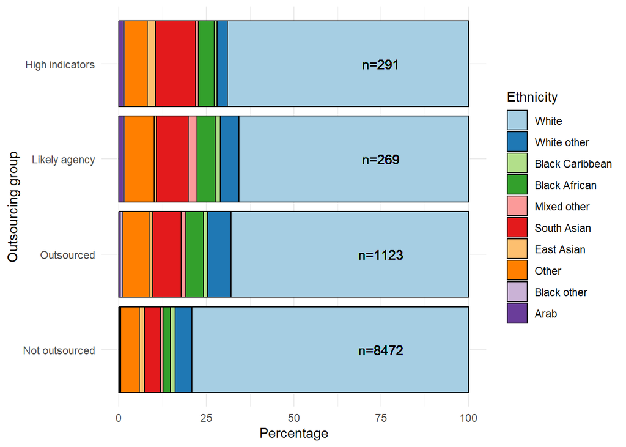

```r
data %>%
  # get values of labels
  # mutate_all(haven::as_factor) %>%
  group_by(outsourcing_group, Ethnicity_collapsed) %>%
  summarise(
    Frequency = sum(NatRepemployees),
    n = n()
  ) %>%
  mutate(
    Sum = sum(Frequency),
    Percentage = 100 * (Frequency / Sum),
    N = n()
  ) %>%
  ggplot(., aes(outsourcing_group, Percentage, fill = Ethnicity_collapsed)) +
  geom_col(colour="black") +
  annotate("text", x = ethnicity_statistics$outsourcing_group, y = 75, label = paste0("n=",ethnicity_statistics$N)) +
  coord_flip() +
  scale_fill_manual(values = many_colours, name = "Ethnicity") +
  xlab("Outsourcing group") +
  theme_minimal()
```

```r
# mod <- glm(outsourcing_status ~ Ethnicity_collapsed, data, family="binomial", weights=NatRepemployees)
# summary(mod)
#
# coef_table <- data.frame("estimate" = mod[["coefficients"]]) %>%
#   mutate(
#     or = round(exp(estimate),2)
#   )
```

#### Paysplit[^15]

```r
ethnicity_summary_paysplit <- data %>%
  group_by(outsourcing_status, income_group, Ethnicity_labelled) %>%
  summarise(
    n = n(),
    Frequency = sum(NatRepemployees)
  ) %>%
  mutate(
    N = sum(n),
    Sum = sum(Frequency),
    Percentage = 100 * (Frequency / Sum),
    Ethnicity_short = Ethnicity_labelled
  ) %>%
    separate_wider_delim(Ethnicity_short,
                         names = c("Ethnicity_short", "Ethnicity detail"),
                         delim = stringr::regex(" / |, "),  # use multiple delims
                         too_few = "align_start",
                         too_many = "merge")

readr::write_csv(ethnicity_statistics, file = "../outputs/data/ethnicity_stats_paysplit_1.csv")
```

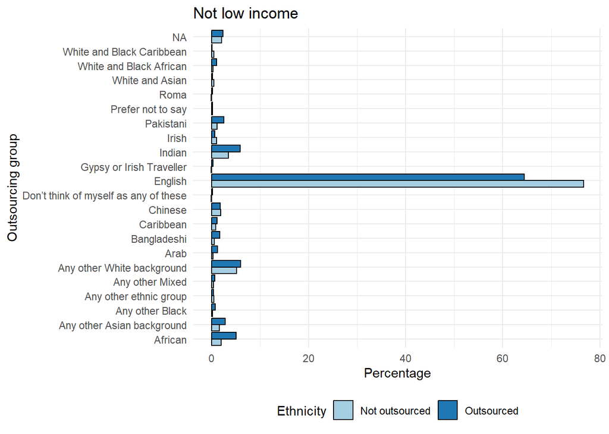

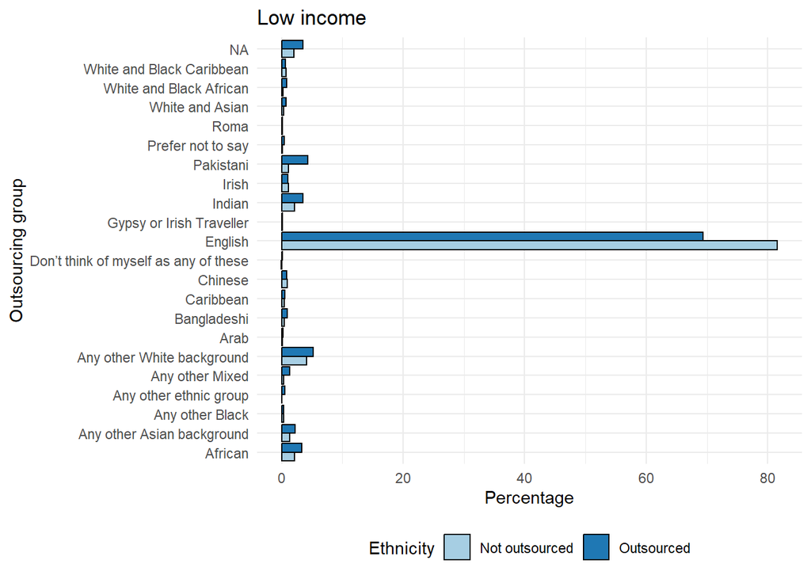

```r
temp_data <-  ethnicity_summary_paysplit %>%
  drop_na(income_group)

for(group in unique(temp_data$income_group)){
  plot_data <- temp_data %>%
    filter(income_group==group)

  plot <- plot_data %>%
    ggplot(., aes(Ethnicity_short, Percentage, fill = outsourcing_status)) +
      geom_col(colour="black", position = position_dodge()) +
      #annotate("text", x = ethnicity_statistics$outsourcing_status, y = 75, label = paste0("n=",ethnicity_statistics$Sum)) +
      coord_flip() +
      scale_fill_manual(values = many_colours, name = "Ethnicity") +
      xlab("Outsourcing group") +
      theme_minimal() +
    theme(
      legend.position = "bottom"
    ) +
    ggtitle(paste0(group, " income"))


  print(plot)
}
```

```r
# ethnicity_summary_paysplit %>%
#   drop_na(income_group) %>%
#   ggplot(., aes(outsourcing_status, Percentage, fill = Ethnicity_short)) +
#   facet_grid(rows=~income_group) +
#   geom_col(colour="black") +
#   #annotate("text", x = ethnicity_statistics$outsourcing_status, y = 75, label = paste0("n=",ethnicity_statistics$Sum)) +
#   coord_flip() +
#   scale_fill_manual(values = many_colours, name = "Ethnicity") +
#   xlab("Outsourcing group") +
#   theme_minimal() +
#   theme(
#     legend.position = "bottom"
#   )
```

```r
ethnicity_summary_paysplit <- data %>%
  group_by(outsourcing_status, income_group, Ethnicity_collapsed) %>%
  summarise(
    n = n(),
    Frequency = sum(NatRepemployees)
  ) %>%
  mutate(
    N = sum(n),
    Sum = sum(Frequency),
    Percentage = 100 * (Frequency / Sum)
  )

#readr::write_csv(ethnicity_statistics, file = "../outputs/data/ethnicity_stats_paysplit_1.csv")
```

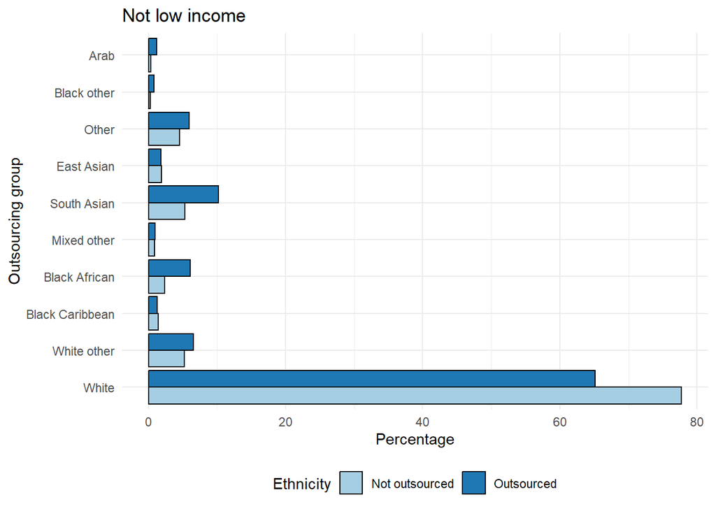

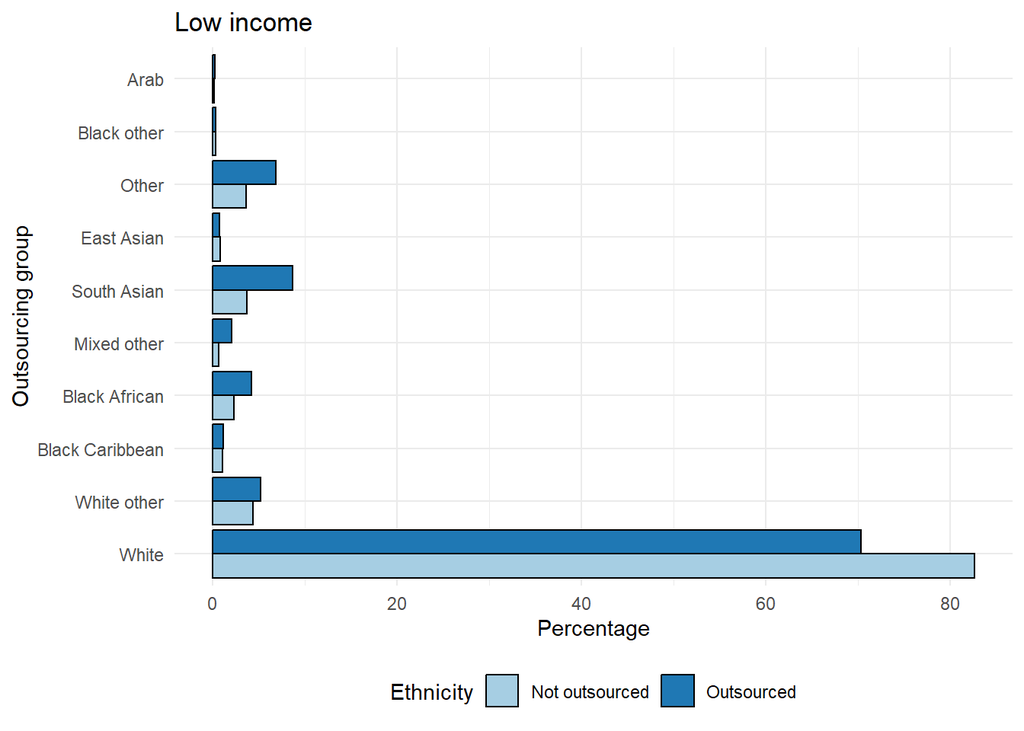

```r
temp_data <-  ethnicity_summary_paysplit %>%
  drop_na(income_group)

for(group in unique(temp_data$income_group)){
  plot_data <- temp_data %>%
    filter(income_group==group)

  plot <- plot_data %>%
    ggplot(., aes(Ethnicity_collapsed, Percentage, fill = outsourcing_status)) +
      geom_col(colour="black", position = position_dodge()) +
      #annotate("text", x = ethnicity_statistics$outsourcing_status, y = 75, label = paste0("n=",ethnicity_statistics$Sum)) +
      coord_flip() +
      scale_fill_manual(values = many_colours, name = "Ethnicity") +
      xlab("Outsourcing group") +
      theme_minimal() +
    theme(
      legend.position = "bottom"
    ) +
    ggtitle(paste0(group, " income"))


  print(plot)
}
```

```r
# ethnicity_summary_paysplit %>%
#   drop_na(income_group) %>%
#   ggplot(., aes(outsourcing_status, Percentage, fill = Ethnicity_short)) +
#   facet_grid(rows=~income_group) +
#   geom_col(colour="black") +
#   #annotate("text", x = ethnicity_statistics$outsourcing_status, y = 75, label = paste0("n=",ethnicity_statistics$Sum)) +
#   coord_flip() +
#   scale_fill_manual(values = many_colours, name = "Ethnicity") +
#   xlab("Outsourcing group") +
#   theme_minimal() +
#   theme(
#     legend.position = "bottom"
#   )
```

```r
mod <- glm(outsourcing_status ~ income_group*Ethnicity_collapsed, data, family="binomial")
summary(mod)
```

```
Call:
glm(formula = outsourcing_status ~ income_group * Ethnicity_collapsed,
    family = "binomial", data = data)

Coefficients:
                                                   Estimate Std. Error z value
(Intercept)                                        -1.83224    0.04438 -41.286
income_groupLow                                     0.17246    0.06883   2.506
Ethnicity_collapsedWhite other                      0.33035    0.16107   2.051
Ethnicity_collapsedBlack Caribbean                 -0.19371    0.31031  -0.624
Ethnicity_collapsedBlack African                    1.23328    0.13921   8.859
Ethnicity_collapsedMixed other                      0.23623    0.28662   0.824
Ethnicity_collapsedSouth Asian                      0.92653    0.14299   6.480
Ethnicity_collapsedEast Asian                       0.17932    0.36655   0.489
Ethnicity_collapsedOther                            0.42737    0.18195   2.349
Ethnicity_collapsedBlack other                      1.19039    0.39319   3.027
Ethnicity_collapsedArab                             1.32142    0.51830   2.550
income_groupLow:Ethnicity_collapsedWhite other     -0.13691    0.27257  -0.502
income_groupLow:Ethnicity_collapsedBlack Caribbean  0.55421    0.45290   1.224
income_groupLow:Ethnicity_collapsedBlack African   -0.44101    0.23655  -1.864
income_groupLow:Ethnicity_collapsedMixed other      0.64585    0.41324   1.563
income_groupLow:Ethnicity_collapsedSouth Asian     -0.01517    0.23811  -0.064
income_groupLow:Ethnicity_collapsedEast Asian      -0.12898    0.73289  -0.176
income_groupLow:Ethnicity_collapsedOther            0.33341    0.27581   1.209
income_groupLow:Ethnicity_collapsedBlack other     -0.70927    0.69591  -1.019
income_groupLow:Ethnicity_collapsedArab            -0.35479    1.33094  -0.267
                                                   Pr(>|z|)
(Intercept)                                         < 2e-16 ***
income_groupLow                                     0.01222 *
Ethnicity_collapsedWhite other                      0.04027 *
Ethnicity_collapsedBlack Caribbean                  0.53246
Ethnicity_collapsedBlack African                    < 2e-16 ***
Ethnicity_collapsedMixed other                      0.40983
Ethnicity_collapsedSouth Asian                     9.19e-11 ***
Ethnicity_collapsedEast Asian                       0.62469
Ethnicity_collapsedOther                            0.01883 *
Ethnicity_collapsedBlack other                      0.00247 **
Ethnicity_collapsedArab                             0.01079 *
income_groupLow:Ethnicity_collapsedWhite other      0.61548
income_groupLow:Ethnicity_collapsedBlack Caribbean  0.22107
income_groupLow:Ethnicity_collapsedBlack African    0.06228 .
income_groupLow:Ethnicity_collapsedMixed other      0.11808
income_groupLow:Ethnicity_collapsedSouth Asian      0.94921
income_groupLow:Ethnicity_collapsedEast Asian       0.86030
income_groupLow:Ethnicity_collapsedOther            0.22673
income_groupLow:Ethnicity_collapsedBlack other      0.30811
income_groupLow:Ethnicity_collapsedArab             0.78980
---
Signif. codes:  0 '***' 0.001 '**' 0.01 '*' 0.05 '.' 0.1 ' ' 1

(Dispersion parameter for binomial family taken to be 1)

    Null deviance: 8127.6  on 8942  degrees of freedom
Residual deviance: 7956.9  on 8923  degrees of freedom
  (1212 observations deleted due to missingness)
AIC: 7996.9

Number of Fisher Scoring iterations: 4
```

```r
test_data <- data %>%
  drop_na(income_group) %>%
  mutate(
    income_group = factor(income_group, levels = c("Not low", "Low")),
    Ethnicity_short = Ethnicity_labelled
  ) %>%
  separate_wider_delim(Ethnicity_short,
                       names = c("Ethnicity_short", "Ethnicity detail"),
                       delim = " / ",
                       too_few = "align_start",
                       too_many = "merge") %>%
  mutate(
    Ethnicity_short = forcats::fct_relevel(factor(Ethnicity_short), "English")
  )


test <- glm(outsourcing_status ~ Age + Gender + income_group + Ethnicity_short, family = "binomial", data = test_data)
summary(test)
```

```
Call:
glm(formula = outsourcing_status ~ Age + Gender + income_group +
    Ethnicity_short, family = "binomial", data = test_data)

Coefficients:
                                                                        Estimate
(Intercept)                                                            -1.122623
Age                                                                    -0.024661
GenderMale                                                              0.531731
GenderOther                                                             0.128987
GenderPrefer not to say                                                -0.240452
income_groupLow                                                         0.276827
Ethnicity_shortAfrican                                                  0.750804
Ethnicity_shortAny other Asian background                               0.691922
Ethnicity_shortAny other Black, Black British, or Caribbean background  0.752002
Ethnicity_shortAny other ethnic group                                   0.220800
Ethnicity_shortAny other Mixed                                          0.673451
Ethnicity_shortAny other White background                               0.171750
Ethnicity_shortArab                                                     0.989803
Ethnicity_shortBangladeshi                                              0.703248
Ethnicity_shortCaribbean                                                0.183752
Ethnicity_shortChinese                                                  0.021374
Ethnicity_shortDon’t think of myself as any of these                    1.449163
Ethnicity_shortGypsy or Irish Traveller                                 0.282974
Ethnicity_shortIndian                                                   0.548848
Ethnicity_shortIrish                                                   -0.126226
Ethnicity_shortPakistani                                                0.864916
Ethnicity_shortPrefer not to say                                       -0.006321
Ethnicity_shortRoma                                                     1.082635
Ethnicity_shortWhite and Asian                                         -0.090237
Ethnicity_shortWhite and Black African                                  1.155726
Ethnicity_shortWhite and Black Caribbean                               -0.279236
                                                                       Std. Error
(Intercept)                                                              0.111181
Age                                                                      0.002392
GenderMale                                                               0.061348
GenderOther                                                              0.780590
GenderPrefer not to say                                                  1.056849
income_groupLow                                                          0.061893
Ethnicity_shortAfrican                                                   0.125846
```

[output cut: 96 more lines]

```
Ethnicity_shortRoma
Ethnicity_shortWhite and Asian
Ethnicity_shortWhite and Black African                                 ***
Ethnicity_shortWhite and Black Caribbean
---
Signif. codes:  0 '***' 0.001 '**' 0.01 '*' 0.05 '.' 0.1 ' ' 1

(Dispersion parameter for binomial family taken to be 1)

    Null deviance: 7918.6  on 8739  degrees of freedom
Residual deviance: 7567.2  on 8714  degrees of freedom
  (203 observations deleted due to missingness)
AIC: 7619.2

Number of Fisher Scoring iterations: 4
```

Another way of looking at this is to calculate, for each ethnicity, the proportion of workers in each outsourcing group. Doing so yields the plot below.[^16]

```r
ethnicity_statistics <- data %>%
  # get values of labels
  # mutate_all(haven::as_factor) %>%
  group_by(Ethnicity, outsourcing_status) %>%
  summarise(
    Frequency = n()
  ) %>%
  mutate(
    Sum = sum(Frequency),
    Percentage = 100 * (Frequency / Sum)
  ) %>%
  rename(
    `Outsourcing group` = outsourcing_status
  )

ethnicity_statistics %>%
  mutate(
    Ethnicity = haven::as_factor(Ethnicity)
    ) %>%
  knitr::kable(.,digits = 2) %>%
  kable_styling(full_width = F)
```

| Ethnicity | Outsourcing group | Frequency | Sum | Percentage |
| --- | --- | --- | --- | --- |
| English / Welsh / Scottish / Northern Irish / British | Not outsourced | 6623 | 7747 | 85.49 |
| English / Welsh / Scottish / Northern Irish / British | Outsourced | 1124 | 7747 | 14.51 |
| Irish | Not outsourced | 111 | 128 | 86.72 |
| Irish | Outsourced | 17 | 128 | 13.28 |
| Gypsy or Irish Traveller | Not outsourced | 6 | 8 | 75.00 |
| Gypsy or Irish Traveller | Outsourced | 2 | 8 | 25.00 |
| Roma | Not outsourced | 4 | 7 | 57.14 |
| Roma | Outsourced | 3 | 7 | 42.86 |
| Any other White background | Not outsourced | 369 | 449 | 82.18 |
| Any other White background | Outsourced | 80 | 449 | 17.82 |
| White and Black Caribbean | Not outsourced | 84 | 95 | 88.42 |
| White and Black Caribbean | Outsourced | 11 | 95 | 11.58 |
| White and Black African | Not outsourced | 40 | 66 | 60.61 |
| White and Black African | Outsourced | 26 | 66 | 39.39 |
| White and Asian | Not outsourced | 61 | 73 | 83.56 |
| White and Asian | Outsourced | 12 | 73 | 16.44 |
| Any other Mixed / Multiple ethnic background | Not outsourced | 59 | 82 | 71.95 |
| Any other Mixed / Multiple ethnic background | Outsourced | 23 | 82 | 28.05 |
| Indian | Not outsourced | 170 | 225 | 75.56 |
| Indian | Outsourced | 55 | 225 | 24.44 |
| Pakistani | Not outsourced | 93 | 142 | 65.49 |
| Pakistani | Outsourced | 49 | 142 | 34.51 |
| Bangladeshi | Not outsourced | 47 | 68 | 69.12 |
| Bangladeshi | Outsourced | 21 | 68 | 30.88 |
| Chinese | Not outsourced | 70 | 82 | 85.37 |
| Chinese | Outsourced | 12 | 82 | 14.63 |
| Any other Asian background | Not outsourced | 57 | 83 | 68.67 |
| Any other Asian background | Outsourced | 26 | 83 | 31.33 |
| African | Not outsourced | 232 | 343 | 67.64 |
| African | Outsourced | 111 | 343 | 32.36 |
| Caribbean | Not outsourced | 74 | 89 | 83.15 |
| Caribbean | Outsourced | 15 | 89 | 16.85 |
| Any other Black, Black British, or Caribbean background | Not outsourced | 36 | 52 | 69.23 |
| Any other Black, Black British, or Caribbean background | Outsourced | 16 | 52 | 30.77 |
| Arab | Not outsourced | 12 | 19 | 63.16 |
| Arab | Outsourced | 7 | 19 | 36.84 |
| Any other ethnic group | Not outsourced | 13 | 16 | 81.25 |
| Any other ethnic group | Outsourced | 3 | 16 | 18.75 |
| Don’t think of myself as any of these | Not outsourced | 7 | 12 | 58.33 |
| Don’t think of myself as any of these | Outsourced | 5 | 12 | 41.67 |
| Prefer not to say | Not outsourced | 22 | 26 | 84.62 |
| Prefer not to say | Outsourced | 4 | 26 | 15.38 |
| NA | Not outsourced | 282 | 343 | 82.22 |
| NA | Outsourced | 61 | 343 | 17.78 |

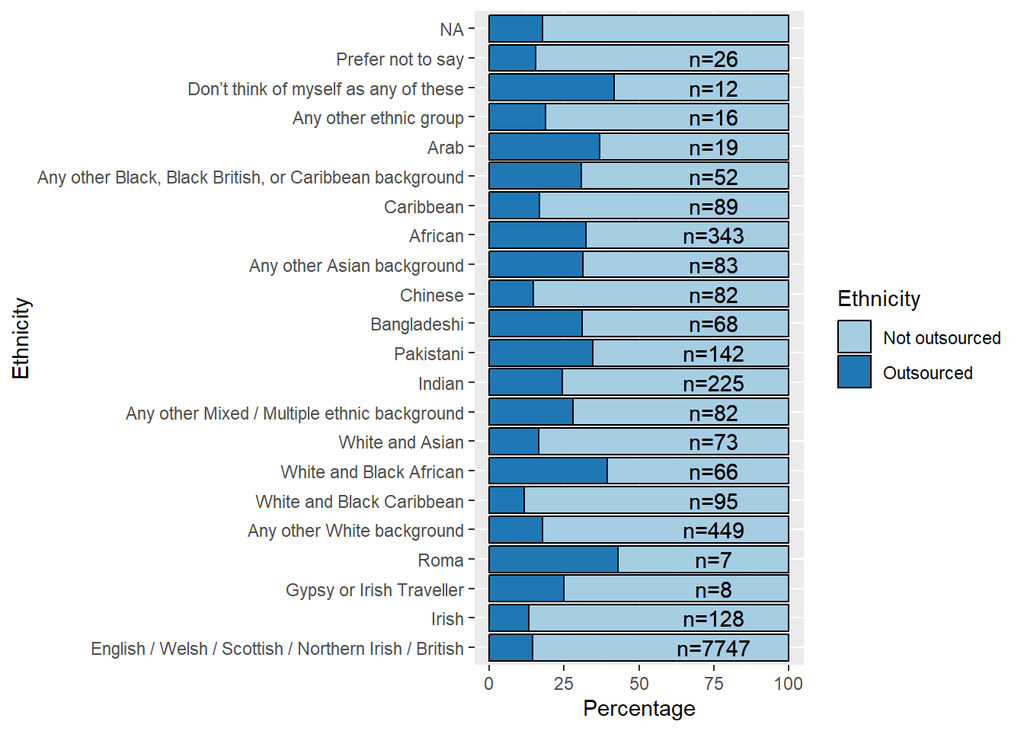

```r
# ordering_df <- ethnicity_statistics %>%
#   filter(`Outsourcing group` == "Outsourced") %>%
#   mutate(
#     Ethnicity = haven::as_factor(Ethnicity),
#     Ethnicity = factor(Ethnicity),
#     Ethnicity = forcats::fct_reorder(Ethnicity, Percentage)
#   )

ethnicity_statistics %>%
  mutate(
    Ethnicity = haven::as_factor(Ethnicity)
    ) %>%
  ggplot(., aes(Ethnicity, Percentage, fill = `Outsourcing group`)) +
  geom_col(colour="black") +
  annotate("text", x = ethnicity_statistics$Ethnicity, y = 75, label = paste0("n=", ethnicity_statistics$Sum)) +
  coord_flip() +
  scale_fill_manual(values=many_colours, name = "Ethnicity")
```

```r
write_csv(ethnicity_statistics, file="../outputs/data/ethnicity_stats_2.csv")
```